# Part I - (Ford GoBike System Data)

## by (Ayodele Ayodeji Fortunate)

## Introduction

This dataset includes information about individual rides made in a bike-sharing system covering the greater San Francisco Bay area. The data consists of information regarding 183,412 member's individual trip, including duration in seconds, start time, end time, start station_id and bike share for all trip among others as we see in the variable description bellow.

**- Duration_sec:** This is the duration of trip per member in seconds.

**- start_time:** This include the information about the start time and date for each trip.

**- end_time:** This include the information about the end time and date for each trip.

**- start_station_id:** Take-off station identification number.

**- start_station_name:** Take-off station name.

**- start_station_latitude:** Location of start station in terms of latitude.

**- start_station_longitude:** Location of start station in terms of longitude.

**- end_station_id:** Identification number of station where members ends their trips.

**- end_station_name:** Name of stations where members ends their trips.

**- end_station_latitude:** Location of end station in terms of latitude.

**- end_station_longitude:** Location of end station in terms of longitude.

**- bike_id:** This is the identification number of Bike used for each trip.

**- user_type:** Types of members engaging with the bike trips. whether customer or suscribers.

**- member_birth_year:** Birth year of members.

**- member_gender:** Sex of members engaging with the bike trips. We have Male, Female and Others.

**- bike_share_for_all_trip:** This tells wether members share their ride or not throughout their entire trip.

## Preliminary Wrangling

```python
# import all packages and set plots to be embedded inline
import numpy as np
import pandas as pd
import matplotlib.pyplot as plt
import seaborn as sb
import datetime as dt
import calendar
%matplotlib inline
```

### Setting the color for the entire notebook

```python
sb.set_style('darkgrid') # set grid color
sb.set_palette('Set2') # set color palette
```

**Loading dataset into pandas dataframe and checking for the total number of entries, datatype of each variables and displaying the first 10 rows of the dataset**

```python
# loading dataset into pandas dataframe
df_bike_data = pd.read_csv ('201902-fordgobike-tripdata.csv')
```

```python
# displaying the first 10 rows
df_bike_data.head(10)
```

|  | duration_sec | start_time | end_time | start_station_id | start_station_name | start_station_latitude | start_station_longitude | end_station_id | end_station_name | end_station_latitude | end_station_longitude | bike_id | user_type | member_birth_year | member_gender | bike_share_for_all_trip |
| --- | --- | --- | --- | --- | --- | --- | --- | --- | --- | --- | --- | --- | --- | --- | --- | --- |
| 0 | 52185 | 2019-02-28 17:32:10.1450 | 2019-03-01 08:01:55.9750 | 21.0 | Montgomery St BART Station (Market St at 2nd St) | 37.789625 | -122.400811 | 13.0 | Commercial St at Montgomery St | 37.794231 | -122.402923 | 4902 | Customer | 1984.0 | Male | No |
| 1 | 42521 | 2019-02-28 18:53:21.7890 | 2019-03-01 06:42:03.0560 | 23.0 | The Embarcadero at Steuart St | 37.791464 | -122.391034 | 81.0 | Berry St at 4th St | 37.775880 | -122.393170 | 2535 | Customer | NaN | NaN | No |
| 2 | 61854 | 2019-02-28 12:13:13.2180 | 2019-03-01 05:24:08.1460 | 86.0 | Market St at Dolores St | 37.769305 | -122.426826 | 3.0 | Powell St BART Station (Market St at 4th St) | 37.786375 | -122.404904 | 5905 | Customer | 1972.0 | Male | No |
| 3 | 36490 | 2019-02-28 17:54:26.0100 | 2019-03-01 04:02:36.8420 | 375.0 | Grove St at Masonic Ave | 37.774836 | -122.446546 | 70.0 | Central Ave at Fell St | 37.773311 | -122.444293 | 6638 | Subscriber | 1989.0 | Other | No |
| 4 | 1585 | 2019-02-28 23:54:18.5490 | 2019-03-01 00:20:44.0740 | 7.0 | Frank H Ogawa Plaza | 37.804562 | -122.271738 | 222.0 | 10th Ave at E 15th St | 37.792714 | -122.248780 | 4898 | Subscriber | 1974.0 | Male | Yes |
| 5 | 1793 | 2019-02-28 23:49:58.6320 | 2019-03-01 00:19:51.7600 | 93.0 | 4th St at Mission Bay Blvd S | 37.770407 | -122.391198 | 323.0 | Broadway at Kearny | 37.798014 | -122.405950 | 5200 | Subscriber | 1959.0 | Male | No |
| 6 | 1147 | 2019-02-28 23:55:35.1040 | 2019-03-01 00:14:42.5880 | 300.0 | Palm St at Willow St | 37.317298 | -121.884995 | 312.0 | San Jose Diridon Station | 37.329732 | -121.901782 | 3803 | Subscriber | 1983.0 | Female | No |
| 7 | 1615 | 2019-02-28 23:41:06.7660 | 2019-03-01 00:08:02.7560 | 10.0 | Washington St at Kearny St | 37.795393 | -122.404770 | 127.0 | Valencia St at 21st St | 37.756708 | -122.421025 | 6329 | Subscriber | 1989.0 | Male | No |
| 8 | 1570 | 2019-02-28 23:41:48.7900 | 2019-03-01 00:07:59.7150 | 10.0 | Washington St at Kearny St | 37.795393 | -122.404770 | 127.0 | Valencia St at 21st St | 37.756708 | -122.421025 | 6548 | Subscriber | 1988.0 | Other | No |
| 9 | 1049 | 2019-02-28 23:49:47.6990 | 2019-03-01 00:07:17.0250 | 19.0 | Post St at Kearny St | 37.788975 | -122.403452 | 121.0 | Mission Playground | 37.759210 | -122.421339 | 6488 | Subscriber | 1992.0 | Male | No |

```python
# displaying the shape of the dataframe
df_bike_data.shape
```

```
(183412, 16)
```

```python
# checking for the datatype of the variables
print(df_bike_data.dtypes)
```

```
duration_sec                 int64
start_time                  object
end_time                    object
start_station_id           float64
start_station_name          object
start_station_latitude     float64
start_station_longitude    float64
end_station_id             float64
end_station_name            object
end_station_latitude       float64
end_station_longitude      float64
bike_id                      int64
user_type                   object
member_birth_year          float64
member_gender               object
bike_share_for_all_trip     object
dtype: object
```

```python
# checking the statistical information of numerical variables in the dataset
df_bike_data.describe()
```

|  | duration_sec | start_station_id | start_station_latitude | start_station_longitude | end_station_id | end_station_latitude | end_station_longitude | bike_id | member_birth_year |
| --- | --- | --- | --- | --- | --- | --- | --- | --- | --- |
| count | 183412.000000 | 183215.000000 | 183412.000000 | 183412.000000 | 183215.000000 | 183412.000000 | 183412.000000 | 183412.000000 | 175147.000000 |
| mean | 726.078435 | 138.590427 | 37.771223 | -122.352664 | 136.249123 | 37.771427 | -122.352250 | 4472.906375 | 1984.806437 |
| std | 1794.389780 | 111.778864 | 0.099581 | 0.117097 | 111.515131 | 0.099490 | 0.116673 | 1664.383394 | 10.116689 |
| min | 61.000000 | 3.000000 | 37.317298 | -122.453704 | 3.000000 | 37.317298 | -122.453704 | 11.000000 | 1878.000000 |
| 25% | 325.000000 | 47.000000 | 37.770083 | -122.412408 | 44.000000 | 37.770407 | -122.411726 | 3777.000000 | 1980.000000 |
| 50% | 514.000000 | 104.000000 | 37.780760 | -122.398285 | 100.000000 | 37.781010 | -122.398279 | 4958.000000 | 1987.000000 |
| 75% | 796.000000 | 239.000000 | 37.797280 | -122.286533 | 235.000000 | 37.797320 | -122.288045 | 5502.000000 | 1992.000000 |
| max | 85444.000000 | 398.000000 | 37.880222 | -121.874119 | 398.000000 | 37.880222 | -121.874119 | 6645.000000 | 2001.000000 |

```python
# checking for the columns with null values
df_bike_data.isnull().any()
```

```
duration_sec               False
start_time                 False
end_time                   False
start_station_id            True
start_station_name          True
start_station_latitude     False
start_station_longitude    False
end_station_id              True
end_station_name            True
end_station_latitude       False
end_station_longitude      False
bike_id                    False
user_type                  False
member_birth_year           True
member_gender               True
bike_share_for_all_trip    False
dtype: bool
```

**This implies that there are null values in our dataset**

From the above, I discovered that 6 columns which are **start_station_id**, **start_station_name**, **end_station_id**, **end_station_name**, **member_birth_year** and **member_gender** are having null values

```python
# taking deep look at the entire dataset where **start_station_id** is null
df_bike_data[df_bike_data['start_station_id'].isnull()]
```

|  | duration_sec | start_time | end_time | start_station_id | start_station_name | start_station_latitude | start_station_longitude | end_station_id | end_station_name | end_station_latitude | end_station_longitude | bike_id | user_type | member_birth_year | member_gender | bike_share_for_all_trip |
| --- | --- | --- | --- | --- | --- | --- | --- | --- | --- | --- | --- | --- | --- | --- | --- | --- |
| 475 | 1709 | 2019-02-28 20:55:53.9320 | 2019-02-28 21:24:23.7380 | NaN | NaN | 37.40 | -121.94 | NaN | NaN | 37.40 | -121.93 | 4211 | Customer | 1991.0 | Female | No |
| 1733 | 1272 | 2019-02-28 18:32:34.2730 | 2019-02-28 18:53:46.7270 | NaN | NaN | 37.40 | -121.94 | NaN | NaN | 37.41 | -121.96 | 4174 | Subscriber | 1980.0 | Male | No |
| 3625 | 142 | 2019-02-28 17:10:46.5290 | 2019-02-28 17:13:09.4310 | NaN | NaN | 37.41 | -121.95 | NaN | NaN | 37.41 | -121.96 | 4283 | Subscriber | 1988.0 | Male | No |
| 4070 | 585 | 2019-02-28 16:28:45.9340 | 2019-02-28 16:38:31.3320 | NaN | NaN | 37.39 | -121.93 | NaN | NaN | 37.40 | -121.92 | 4089 | Subscriber | 1984.0 | Male | Yes |
| 5654 | 509 | 2019-02-28 12:30:17.1310 | 2019-02-28 12:38:46.3290 | NaN | NaN | 37.40 | -121.92 | NaN | NaN | 37.39 | -121.93 | 4089 | Subscriber | 1984.0 | Male | Yes |
| ... | ... | ... | ... | ... | ... | ... | ... | ... | ... | ... | ... | ... | ... | ... | ... | ... |
| 176154 | 1447 | 2019-02-02 12:03:04.5440 | 2019-02-02 12:27:12.2670 | NaN | NaN | 37.40 | -121.93 | NaN | NaN | 37.40 | -121.93 | 4249 | Customer | 1984.0 | Male | No |
| 179730 | 309 | 2019-02-01 12:59:45.9690 | 2019-02-01 13:04:55.4260 | NaN | NaN | 37.40 | -121.94 | NaN | NaN | 37.40 | -121.93 | 4249 | Customer | 1987.0 | Female | No |
| 179970 | 659 | 2019-02-01 12:17:37.6750 | 2019-02-01 12:28:37.0140 | NaN | NaN | 37.41 | -121.96 | NaN | NaN | 37.41 | -121.94 | 4092 | Subscriber | 1999.0 | Female | No |
| 180106 | 2013 | 2019-02-01 11:33:55.1470 | 2019-02-01 12:07:28.9400 | NaN | NaN | 37.40 | -121.94 | NaN | NaN | 37.40 | -121.94 | 4251 | Customer | 1990.0 | Female | No |
| 181201 | 312 | 2019-02-01 09:26:34.8030 | 2019-02-01 09:31:46.9210 | NaN | NaN | 37.40 | -121.93 | NaN | NaN | 37.40 | -121.93 | 4208 | Subscriber | 1987.0 | Male | No |

197 rows × 16 columns

```python
# taking deep look at the entire dataset where **member_gender** is null
df_bike_data[df_bike_data['member_gender'].isnull()]
```

|  | duration_sec | start_time | end_time | start_station_id | start_station_name | start_station_latitude | start_station_longitude | end_station_id | end_station_name | end_station_latitude | end_station_longitude | bike_id | user_type | member_birth_year | member_gender | bike_share_for_all_trip |
| --- | --- | --- | --- | --- | --- | --- | --- | --- | --- | --- | --- | --- | --- | --- | --- | --- |
| 1 | 42521 | 2019-02-28 18:53:21.7890 | 2019-03-01 06:42:03.0560 | 23.0 | The Embarcadero at Steuart St | 37.791464 | -122.391034 | 81.0 | Berry St at 4th St | 37.775880 | -122.393170 | 2535 | Customer | NaN | NaN | No |
| 13 | 915 | 2019-02-28 23:49:06.0620 | 2019-03-01 00:04:21.8670 | 252.0 | Channing Way at Shattuck Ave | 37.865847 | -122.267443 | 244.0 | Shattuck Ave at Hearst Ave | 37.873676 | -122.268487 | 5101 | Subscriber | NaN | NaN | No |
| 28 | 650 | 2019-02-28 23:43:27.5030 | 2019-02-28 23:54:18.4510 | 258.0 | University Ave at Oxford St | 37.872355 | -122.266447 | 263.0 | Channing Way at San Pablo Ave | 37.862827 | -122.290231 | 4784 | Customer | NaN | NaN | No |
| 53 | 3418 | 2019-02-28 22:41:16.3620 | 2019-02-28 23:38:14.3630 | 11.0 | Davis St at Jackson St | 37.797280 | -122.398436 | 11.0 | Davis St at Jackson St | 37.797280 | -122.398436 | 319 | Customer | NaN | NaN | No |
| 65 | 926 | 2019-02-28 23:17:05.8530 | 2019-02-28 23:32:32.6820 | 13.0 | Commercial St at Montgomery St | 37.794231 | -122.402923 | 81.0 | Berry St at 4th St | 37.775880 | -122.393170 | 2951 | Subscriber | NaN | NaN | No |
| ... | ... | ... | ... | ... | ... | ... | ... | ... | ... | ... | ... | ... | ... | ... | ... | ... |
| 183354 | 449 | 2019-02-01 01:35:07.6630 | 2019-02-01 01:42:36.8780 | 244.0 | Shattuck Ave at Hearst Ave | 37.873676 | -122.268487 | 253.0 | Haste St at College Ave | 37.866418 | -122.253799 | 5430 | Customer | NaN | NaN | No |
| 183356 | 795 | 2019-02-01 01:25:50.3660 | 2019-02-01 01:39:05.9500 | 368.0 | Myrtle St at Polk St | 37.785434 | -122.419622 | 125.0 | 20th St at Bryant St | 37.759200 | -122.409851 | 5400 | Subscriber | NaN | NaN | No |
| 183363 | 673 | 2019-02-01 01:12:24.4200 | 2019-02-01 01:23:37.6450 | 75.0 | Market St at Franklin St | 37.773793 | -122.421239 | 133.0 | Valencia St at 22nd St | 37.755213 | -122.420975 | 5166 | Customer | NaN | NaN | No |
| 183371 | 196 | 2019-02-01 01:08:38.6410 | 2019-02-01 01:11:54.9490 | 58.0 | Market St at 10th St | 37.776619 | -122.417385 | 75.0 | Market St at Franklin St | 37.773793 | -122.421239 | 2395 | Customer | NaN | NaN | No |
| 183402 | 122 | 2019-02-01 00:17:32.2580 | 2019-02-01 00:19:34.9380 | 119.0 | 18th St at Noe St | 37.761047 | -122.432642 | 120.0 | Mission Dolores Park | 37.761420 | -122.426435 | 4326 | Subscriber | NaN | NaN | No |

8265 rows × 16 columns

```python
df_bike_data.duplicated().sum()
```

```
0
```

**There is no duplicate row in the entire dataset**

### Modifications to be done on the dataset

**I decided to do this based on the nature of my analysis and the key findinds I have in mind**

1. Remove null values in the dataset
2. start_time and end_time should be in datetime not object
3. start_time and the end_time should be split into time of the day, day of the week and month of the year. This is necessary for my analysis
4. Data type of member_birth_year should be Change to integer
5. Extract the actual age of members from member_birth_year provided and assign age group to members age
6. add duration_min column
7. Drop the columns that are not needed for the analysis

### Cleaning up the data to ease my analysis

```python
# make a copy of the original dataset
df_bike_data_clean = df_bike_data.copy()
```

```python
df_bike_data_clean.head(5)
```

|  | duration_sec | start_time | end_time | start_station_id | start_station_name | start_station_latitude | start_station_longitude | end_station_id | end_station_name | end_station_latitude | end_station_longitude | bike_id | user_type | member_birth_year | member_gender | bike_share_for_all_trip |
| --- | --- | --- | --- | --- | --- | --- | --- | --- | --- | --- | --- | --- | --- | --- | --- | --- |
| 0 | 52185 | 2019-02-28 17:32:10.1450 | 2019-03-01 08:01:55.9750 | 21.0 | Montgomery St BART Station (Market St at 2nd St) | 37.789625 | -122.400811 | 13.0 | Commercial St at Montgomery St | 37.794231 | -122.402923 | 4902 | Customer | 1984.0 | Male | No |
| 1 | 42521 | 2019-02-28 18:53:21.7890 | 2019-03-01 06:42:03.0560 | 23.0 | The Embarcadero at Steuart St | 37.791464 | -122.391034 | 81.0 | Berry St at 4th St | 37.775880 | -122.393170 | 2535 | Customer | NaN | NaN | No |
| 2 | 61854 | 2019-02-28 12:13:13.2180 | 2019-03-01 05:24:08.1460 | 86.0 | Market St at Dolores St | 37.769305 | -122.426826 | 3.0 | Powell St BART Station (Market St at 4th St) | 37.786375 | -122.404904 | 5905 | Customer | 1972.0 | Male | No |
| 3 | 36490 | 2019-02-28 17:54:26.0100 | 2019-03-01 04:02:36.8420 | 375.0 | Grove St at Masonic Ave | 37.774836 | -122.446546 | 70.0 | Central Ave at Fell St | 37.773311 | -122.444293 | 6638 | Subscriber | 1989.0 | Other | No |
| 4 | 1585 | 2019-02-28 23:54:18.5490 | 2019-03-01 00:20:44.0740 | 7.0 | Frank H Ogawa Plaza | 37.804562 | -122.271738 | 222.0 | 10th Ave at E 15th St | 37.792714 | -122.248780 | 4898 | Subscriber | 1974.0 | Male | Yes |

### Dealing with issue 1

Removing the null values from **start_station_id**, **start_station_name**, **end_station_id**, **end_station_name**, **member_birth_year** and **member_gender** column.

**I decided to remove the null values in columns specified above because the columns are the key metric in my analysis and as the null values could affect my visuals**.

### Code

```python
# droping null value from the dataset
df_bike_data_clean.dropna(inplace  = True)
```

### Test

```python
df_bike_data_clean[df_bike_data_clean['member_birth_year'].isnull()]
```

|  | duration_sec | start_time | end_time | start_station_id | start_station_name | start_station_latitude | start_station_longitude | end_station_id | end_station_name | end_station_latitude | end_station_longitude | bike_id | user_type | member_birth_year | member_gender | bike_share_for_all_trip |
| --- | --- | --- | --- | --- | --- | --- | --- | --- | --- | --- | --- | --- | --- | --- | --- | --- |

```python
df_bike_data_clean[df_bike_data_clean['member_gender'].isnull()]
```

|  | duration_sec | start_time | end_time | start_station_id | start_station_name | start_station_latitude | start_station_longitude | end_station_id | end_station_name | end_station_latitude | end_station_longitude | bike_id | user_type | member_birth_year | member_gender | bike_share_for_all_trip |
| --- | --- | --- | --- | --- | --- | --- | --- | --- | --- | --- | --- | --- | --- | --- | --- | --- |

```python
df_bike_data_clean.shape
```

```
(174952, 16)
```

After dropping the null values the structure of the dataset reduced to **174952** total trips from original total trip of **183412** while the numbers of features remain unchanged (**16**)

### Dealing with issue 2

Changing the data type of start_time and end_time

### Code

```python
# converting the given start time and end time into datetime
df_bike_data_clean['start_time'] = pd.to_datetime(df_bike_data['start_time'])
df_bike_data_clean['end_time'] = pd.to_datetime(df_bike_data['end_time'])
```

### Test

```python
# checking for the info of the dataframe
df_bike_data_clean.info()
```

```
<class 'pandas.core.frame.DataFrame'>
Int64Index: 174952 entries, 0 to 183411
Data columns (total 16 columns):
 #   Column                   Non-Null Count   Dtype
---  ------                   --------------   -----
 0   duration_sec             174952 non-null  int64
 1   start_time               174952 non-null  datetime64[ns]
 2   end_time                 174952 non-null  datetime64[ns]
 3   start_station_id         174952 non-null  float64
 4   start_station_name       174952 non-null  object
 5   start_station_latitude   174952 non-null  float64
 6   start_station_longitude  174952 non-null  float64
 7   end_station_id           174952 non-null  float64
 8   end_station_name         174952 non-null  object
 9   end_station_latitude     174952 non-null  float64
 10  end_station_longitude    174952 non-null  float64
 11  bike_id                  174952 non-null  int64
 12  user_type                174952 non-null  object
 13  member_birth_year        174952 non-null  float64
 14  member_gender            174952 non-null  object
 15  bike_share_for_all_trip  174952 non-null  object
dtypes: datetime64[ns](2), float64(7), int64(2), object(5)
memory usage: 22.7+ MB
```

### Dealing with issue 3

split the start_time and the end_time into time of the day, day of the week and month of the year

### Code

**Extracting Time of the day using time function in pandas**

Here is a list of different parts of the day. There is no exact time when each one begins and ends, because they can vary according to your lifestyle and the hours of daylight at each time of year, but this list shows some approximate times that many people would agree with.

**Parts of the Day**

source [Reference](https://www.britannica.com/dictionary/eb/qa/parts-of-the-day-early-morning-late-morning-etc)

```python
# Extracting hour of the day from start time using datatime function in pandas
df_bike_data_clean['start_time_hour'] = df_bike_data_clean['start_time'].dt.hour

df_bike_data_clean['start_day_time'] = 'Morning'
df_bike_data_clean['start_day_time'][(df_bike_data_clean['start_time_hour'] >= 12) & (df_bike_data_clean['start_time_hour'] <= 16)] = 'Afternoon'
df_bike_data_clean['start_day_time'][(df_bike_data_clean['start_time_hour'] >= 17) & (df_bike_data_clean['start_time_hour'] <=20)] = 'Evening'
df_bike_data_clean['start_day_time'][(df_bike_data_clean['start_time_hour'] >= 21) & (df_bike_data_clean['start_time_hour'] <= 23)] = 'Night'
```

```python
# Extracting hour of the day from end time using datatime function in pandas
df_bike_data_clean['end_time_hour'] = df_bike_data_clean['end_time'].dt.hour

df_bike_data_clean['end_day_time'] = 'Morning'
df_bike_data_clean['end_day_time'][(df_bike_data_clean['end_time_hour'] >= 12) & (df_bike_data_clean['end_time_hour'] <= 16)] = 'Afternoon'
df_bike_data_clean['end_day_time'][(df_bike_data_clean['end_time_hour'] >= 17) & (df_bike_data_clean['end_time_hour'] <=20)] = 'Evening'
df_bike_data_clean['end_day_time'][(df_bike_data_clean['end_time_hour'] >= 21) & (df_bike_data_clean['end_time_hour'] <= 23)] = 'Night'
```

```python
df_bike_data_clean.sample(30)
```

|  | duration_sec | start_time | end_time | start_station_id | start_station_name | start_station_latitude | start_station_longitude | end_station_id | end_station_name | end_station_latitude | end_station_longitude | bike_id | user_type | member_birth_year | member_gender | bike_share_for_all_trip | start_time_hour | start_day_time | end_time_hour | end_day_time |
| --- | --- | --- | --- | --- | --- | --- | --- | --- | --- | --- | --- | --- | --- | --- | --- | --- | --- | --- | --- | --- |
| 167696 | 222 | 2019-02-04 17:02:05.256 | 2019-02-04 17:05:48.068 | 245.0 | Downtown Berkeley BART | 37.870139 | -122.268422 | 251.0 | California St at University Ave | 37.870555 | -122.279720 | 3089 | Subscriber | 1994.0 | Male | No | 17 | Evening | 17 | Evening |
| 70243 | 279 | 2019-02-19 18:31:31.590 | 2019-02-19 18:36:11.292 | 282.0 | Market St at Park St | 37.332426 | -121.890349 | 297.0 | Locust St at Grant St | 37.322980 | -121.887931 | 4008 | Subscriber | 1995.0 | Male | Yes | 18 | Evening | 18 | Evening |
| 16797 | 355 | 2019-02-27 08:07:55.192 | 2019-02-27 08:13:51.010 | 200.0 | 2nd Ave at E 18th St | 37.800214 | -122.253810 | 163.0 | Lake Merritt BART Station | 37.797320 | -122.265320 | 5620 | Subscriber | 1987.0 | Female | No | 8 | Morning | 8 | Morning |
| 51862 | 264 | 2019-02-21 17:45:43.576 | 2019-02-21 17:50:08.162 | 343.0 | Bryant St at 2nd St | 37.783172 | -122.393572 | 22.0 | Howard St at Beale St | 37.789756 | -122.394643 | 2664 | Subscriber | 1983.0 | Male | No | 17 | Evening | 17 | Evening |
| 113895 | 540 | 2019-02-12 10:34:59.331 | 2019-02-12 10:43:59.588 | 58.0 | Market St at 10th St | 37.776619 | -122.417385 | 21.0 | Montgomery St BART Station (Market St at 2nd St) | 37.789625 | -122.400811 | 1883 | Subscriber | 1991.0 | Female | No | 10 | Morning | 10 | Morning |
| 72551 | 507 | 2019-02-19 16:11:08.237 | 2019-02-19 16:19:36.014 | 373.0 | Potrero del Sol Park (25th St at Utah St) | 37.751792 | -122.405216 | 90.0 | Townsend St at 7th St | 37.771058 | -122.402717 | 5128 | Subscriber | 1987.0 | Male | No | 16 | Afternoon | 16 | Afternoon |
| 92219 | 1099 | 2019-02-15 19:26:52.487 | 2019-02-15 19:45:12.120 | 130.0 | 22nd St Caltrain Station | 37.757288 | -122.392051 | 145.0 | 29th St at Church St | 37.743684 | -122.426806 | 6366 | Subscriber | 1987.0 | Female | No | 19 | Evening | 19 | Evening |
| 85259 | 413 | 2019-02-17 15:42:00.463 | 2019-02-17 15:48:54.194 | 162.0 | Franklin St at 9th St | 37.800516 | -122.272080 | 180.0 | Telegraph Ave at 23rd St | 37.812678 | -122.268773 | 2354 | Subscriber | 1992.0 | Female | No | 15 | Afternoon | 15 | Afternoon |
| 180789 | 630 | 2019-02-01 10:01:52.230 | 2019-02-01 10:12:22.757 | 5.0 | Powell St BART Station (Market St at 5th St) | 37.783899 | -122.408445 | 88.0 | 11th St at Bryant St | 37.770030 | -122.411726 | 1353 | Subscriber | 1990.0 | Male | Yes | 10 | Morning | 10 | Morning |
| 90063 | 1392 | 2019-02-16 13:33:29.427 | 2019-02-16 13:56:42.395 | 24.0 | Spear St at Folsom St | 37.789677 | -122.390428 | 39.0 | Scott St at Golden Gate Ave | 37.778999 | -122.436861 | 6249 | Subscriber | 1993.0 | Male | No | 13 | Afternoon | 13 | Afternoon |
| 90595 | 599 | 2019-02-16 12:03:09.508 | 2019-02-16 12:13:08.798 | 155.0 | Emeryville Public Market | 37.840521 | -122.293528 | 270.0 | Ninth St at Heinz Ave | 37.853489 | -122.289415 | 3291 | Subscriber | 1963.0 | Male | No | 12 | Afternoon | 12 | Afternoon |
| 650 | 128 | 2019-02-28 20:52:40.742 | 2019-02-28 20:54:49.247 | 121.0 | Mission Playground | 37.759210 | -122.421339 | 127.0 | Valencia St at 21st St | 37.756708 | -122.421025 | 4608 | Subscriber | 1962.0 | Male | No | 20 | Evening | 20 | Evening |
| 160168 | 443 | 2019-02-05 17:19:39.193 | 2019-02-05 17:27:02.934 | 37.0 | 2nd St at Folsom St | 37.785000 | -122.395936 | 15.0 | San Francisco Ferry Building (Harry Bridges Pl... | 37.795392 | -122.394203 | 5274 | Customer | 1972.0 | Male | No | 17 | Evening | 17 | Evening |
| 115904 | 185 | 2019-02-12 08:23:17.422 | 2019-02-12 08:26:23.333 | 3.0 | Powell St BART Station (Market St at 4th St) | 37.786375 | -122.404904 | 47.0 | 4th St at Harrison St | 37.780955 | -122.399749 | 4923 | Subscriber | 1961.0 | Male | No | 8 | Morning | 8 | Morning |
| 124105 | 355 | 2019-02-11 08:50:58.910 | 2019-02-11 08:56:54.197 | 98.0 | Valencia St at 16th St | 37.765052 | -122.421866 | 59.0 | S Van Ness Ave at Market St | 37.774814 | -122.418954 | 2576 | Subscriber | 1973.0 | Male | No | 8 | Morning | 8 | Morning |
| 134480 | 592 | 2019-02-08 17:18:42.321 | 2019-02-08 17:28:34.735 | 176.0 | MacArthur BART Station | 37.828410 | -122.266315 | 210.0 | 45th St at Manila | 37.833294 | -122.256224 | 3513 | Subscriber | 1951.0 | Male | No | 17 | Evening | 17 | Evening |
| 137054 | 898 | 2019-02-08 08:55:19.215 | 2019-02-08 09:10:17.755 | 17.0 | Embarcadero BART Station (Beale St at Market St) | 37.792251 | -122.397086 | 126.0 | Esprit Park | 37.761634 | -122.390648 | 5276 | Customer | 1992.0 | Male | No | 8 | Morning | 9 | Morning |
| 146245 | 341 | 2019-02-07 08:55:49.660 | 2019-02-07 09:01:30.963 | 278.0 | The Alameda at Bush St | 37.331932 | -121.904888 | 308.0 | San Pedro Square | 37.336802 | -121.894090 | 2800 | Subscriber | 1990.0 | Male | No | 8 | Morning | 9 | Morning |
| 120840 | 648 | 2019-02-11 16:32:03.746 | 2019-02-11 16:42:51.908 | 50.0 | 2nd St at Townsend St | 37.780526 | -122.390288 | 16.0 | Steuart St at Market St | 37.794130 | -122.394430 | 5574 | Subscriber | 1964.0 | Male | No | 16 | Afternoon | 16 | Afternoon |
| 62758 | 195 | 2019-02-20 16:34:06.583 | 2019-02-20 16:37:22.517 | 90.0 | Townsend St at 7th St | 37.771058 | -122.402717 | 67.0 | San Francisco Caltrain Station 2 (Townsend St... | 37.776639 | -122.395526 | 6110 | Subscriber | 1990.0 | Female | No | 16 | Afternoon | 16 | Afternoon |
| 89716 | 1061 | 2019-02-16 14:40:12.753 | 2019-02-16 14:57:54.348 | 23.0 | The Embarcadero at Steuart St | 37.791464 | -122.391034 | 6.0 | The Embarcadero at Sansome St | 37.804770 | -122.403234 | 6638 | Customer | 1990.0 | Female | No | 14 | Afternoon | 14 | Afternoon |
| 109329 | 267 | 2019-02-12 19:22:26.146 | 2019-02-12 19:26:53.471 | 108.0 | 16th St Mission BART | 37.764710 | -122.419957 | 124.0 | 19th St at Florida St | 37.760447 | -122.410807 | 4991 | Subscriber | 1973.0 | Male | No | 19 | Evening | 19 | Evening |
| 169763 | 444 | 2019-02-04 09:14:54.137 | 2019-02-04 09:22:18.577 | 159.0 | 24th St at Market St | 37.816060 | -122.278244 | 181.0 | Grand Ave at Webster St | 37.811377 | -122.265192 | 4507 | Subscriber | 1965.0 | Male | No | 9 | Morning | 9 | Morning |
| 126767 | 2464 | 2019-02-10 17:03:51.279 | 2019-02-10 17:44:55.486 | 371.0 | Lombard St at Columbus Ave | 37.802746 | -122.413579 | 15.0 | San Francisco Ferry Building (Harry Bridges Pl... | 37.795392 | -122.394203 | 4813 | Subscriber | 1997.0 | Male | No | 17 | Evening | 17 | Evening |
| 26480 | 348 | 2019-02-25 12:14:48.146 | 2019-02-25 12:20:37.111 | 52.0 | McAllister St at Baker St | 37.777416 | -122.441838 | 75.0 | Market St at Franklin St | 37.773793 | -122.421239 | 6530 | Subscriber | 1996.0 | Male | No | 12 | Afternoon | 12 | Afternoon |
| 94593 | 340 | 2019-02-15 16:12:34.529 | 2019-02-15 16:18:15.270 | 55.0 | Webster St at Grove St | 37.777053 | -122.429558 | 43.0 | San Francisco Public Library (Grove St at Hyde... | 37.778768 | -122.415929 | 79 | Subscriber | 1966.0 | Female | No | 16 | Afternoon | 16 | Afternoon |
| 18220 | 685 | 2019-02-26 19:00:25.679 | 2019-02-26 19:11:51.400 | 58.0 | Market St at 10th St | 37.776619 | -122.417385 | 93.0 | 4th St at Mission Bay Blvd S | 37.770407 | -122.391198 | 6126 | Subscriber | 1989.0 | Male | No | 19 | Evening | 19 | Evening |
| 60325 | 515 | 2019-02-20 18:46:03.573 | 2019-02-20 18:54:38.879 | 21.0 | Montgomery St BART Station (Market St at 2nd St) | 37.789625 | -122.400811 | 368.0 | Myrtle St at Polk St | 37.785434 | -122.419622 | 4957 | Subscriber | 1983.0 | Male | No | 18 | Evening | 18 | Evening |
| 100585 | 583 | 2019-02-14 18:12:06.293 | 2019-02-14 18:21:49.750 | 30.0 | San Francisco Caltrain (Townsend St at 4th St) | 37.776598 | -122.395282 | 5.0 | Powell St BART Station (Market St at 5th St) | 37.783899 | -122.408445 | 4442 | Subscriber | 1989.0 | Male | No | 18 | Evening | 18 | Evening |
| 41391 | 853 | 2019-02-22 18:29:04.611 | 2019-02-22 18:43:18.031 | 20.0 | Mechanics Monument Plaza (Market St at Bush St) | 37.791300 | -122.399051 | 76.0 | McCoppin St at Valencia St | 37.771662 | -122.422423 | 4804 | Subscriber | 1987.0 | Female | No | 18 | Evening | 18 | Evening |

**Extracting Days of the week using time function in pandas**

```python
# Exracting week day number for the start trip and the end trip
df_bike_data_clean['start_weekday'] = df_bike_data_clean['start_time'].apply(lambda time: time.dayofweek)
df_bike_data_clean['end_weekday'] = df_bike_data_clean['end_time'].apply(lambda time: time.dayofweek)

# matching each extracted day number to day abbreviation
mapping_day_num = {0:'Mon', 1:'Tue', 2:'Wed', 3:'Thu', 4:'Fri', 5:'Sat', 6:'Sun'}

# creating start and end week column in the existing dataset
df_bike_data_clean['start_weekday'] = df_bike_data_clean['start_weekday'].map(mapping_day_num)
df_bike_data_clean['end_weekday'] = df_bike_data_clean['end_weekday'].map(mapping_day_num)
```

**Extracting Months of the year using time and calender function in pandas**

```python
# Exracting months number of the year for the start trip and the end trip
df_bike_data_clean['start_month'] = df_bike_data_clean['start_time'].apply(lambda time: time.month)
df_bike_data_clean['end_month'] = df_bike_data_clean['end_time'].apply(lambda time: time.month)

# getting the months abbreviation for each month number extracted for both start and end month
df_bike_data_clean['start_month'] = df_bike_data_clean['start_month'].apply(lambda x: calendar.month_abbr[x])
df_bike_data_clean['end_month'] = df_bike_data_clean['end_month'].apply(lambda x: calendar.month_abbr[x])
```

### Test

```python
df_bike_data_clean.info()
```

```
<class 'pandas.core.frame.DataFrame'>
Int64Index: 174952 entries, 0 to 183411
Data columns (total 24 columns):
 #   Column                   Non-Null Count   Dtype
---  ------                   --------------   -----
 0   duration_sec             174952 non-null  int64
 1   start_time               174952 non-null  datetime64[ns]
 2   end_time                 174952 non-null  datetime64[ns]
 3   start_station_id         174952 non-null  float64
 4   start_station_name       174952 non-null  object
 5   start_station_latitude   174952 non-null  float64
 6   start_station_longitude  174952 non-null  float64
 7   end_station_id           174952 non-null  float64
 8   end_station_name         174952 non-null  object
 9   end_station_latitude     174952 non-null  float64
```

[output cut: 16 more lines]

```python
df_bike_data_clean.head(5)
```

|  | duration_sec | start_time | end_time | start_station_id | start_station_name | start_station_latitude | start_station_longitude | end_station_id | end_station_name | end_station_latitude | ... | member_gender | bike_share_for_all_trip | start_time_hour | start_day_time | end_time_hour | end_day_time | start_weekday | end_weekday | start_month | end_month |
| --- | --- | --- | --- | --- | --- | --- | --- | --- | --- | --- | --- | --- | --- | --- | --- | --- | --- | --- | --- | --- | --- |
| 0 | 52185 | 2019-02-28 17:32:10.145 | 2019-03-01 08:01:55.975 | 21.0 | Montgomery St BART Station (Market St at 2nd St) | 37.789625 | -122.400811 | 13.0 | Commercial St at Montgomery St | 37.794231 | ... | Male | No | 17 | Evening | 8 | Morning | Thu | Fri | Feb | Mar |
| 2 | 61854 | 2019-02-28 12:13:13.218 | 2019-03-01 05:24:08.146 | 86.0 | Market St at Dolores St | 37.769305 | -122.426826 | 3.0 | Powell St BART Station (Market St at 4th St) | 37.786375 | ... | Male | No | 12 | Afternoon | 5 | Morning | Thu | Fri | Feb | Mar |
| 3 | 36490 | 2019-02-28 17:54:26.010 | 2019-03-01 04:02:36.842 | 375.0 | Grove St at Masonic Ave | 37.774836 | -122.446546 | 70.0 | Central Ave at Fell St | 37.773311 | ... | Other | No | 17 | Evening | 4 | Morning | Thu | Fri | Feb | Mar |
| 4 | 1585 | 2019-02-28 23:54:18.549 | 2019-03-01 00:20:44.074 | 7.0 | Frank H Ogawa Plaza | 37.804562 | -122.271738 | 222.0 | 10th Ave at E 15th St | 37.792714 | ... | Male | Yes | 23 | Night | 0 | Morning | Thu | Fri | Feb | Mar |
| 5 | 1793 | 2019-02-28 23:49:58.632 | 2019-03-01 00:19:51.760 | 93.0 | 4th St at Mission Bay Blvd S | 37.770407 | -122.391198 | 323.0 | Broadway at Kearny | 37.798014 | ... | Male | No | 23 | Night | 0 | Morning | Thu | Fri | Feb | Mar |

5 rows × 24 columns

### Dealing with issue 4

Change the data type of member_birth_year to integer

### Code

```python
df_bike_data_clean['member_birth_year'] = df_bike_data_clean['member_birth_year'].astype(int)
```

### Test

```python
df_bike_data_clean['member_birth_year']
```

```
0         1984
2         1972
3         1989
4         1974
5         1959
          ...
183407    1996
183408    1984
183409    1990
183410    1988
183411    1989
Name: member_birth_year, Length: 174952, dtype: int32
```

### Dealing with issue 5

Extract the actual age of members from member_birth_year provided and assign age group to members age

### Code

**Extracting the actual age of members from member_birth_year provided**

I decided to use 2019 because it is the only year of consideration

```python
# exctrating the exact member age from their provided birth year
df_bike_data_clean['member_age'] = 2019 - df_bike_data_clean['member_birth_year']

# assigning the extracted member age to age groups
df_bike_data_clean['age_groups'] = pd.cut(df_bike_data_clean['member_age'], [13, 17, 25, 60, 141],
                          labels=['Teenager','Young Adult','Adult','Senior Citizens'])
```

### Test

```python
df_bike_data_clean['age_groups']
```

```
0               Adult
2               Adult
3               Adult
4               Adult
5               Adult
             ...
183407    Young Adult
183408          Adult
183409          Adult
183410          Adult
183411          Adult
Name: age_groups, Length: 174952, dtype: category
Categories (4, object): ['Teenager' < 'Young Adult' < 'Adult' < 'Senior Citizens']
```

```python
df_bike_data_clean.info()
```

```
<class 'pandas.core.frame.DataFrame'>
Int64Index: 174952 entries, 0 to 183411
Data columns (total 26 columns):
 #   Column                   Non-Null Count   Dtype
---  ------                   --------------   -----
 0   duration_sec             174952 non-null  int64
 1   start_time               174952 non-null  datetime64[ns]
 2   end_time                 174952 non-null  datetime64[ns]
 3   start_station_id         174952 non-null  float64
 4   start_station_name       174952 non-null  object
 5   start_station_latitude   174952 non-null  float64
 6   start_station_longitude  174952 non-null  float64
 7   end_station_id           174952 non-null  float64
 8   end_station_name         174952 non-null  object
 9   end_station_latitude     174952 non-null  float64
```

[output cut: 18 more lines]

### Code

```python
# Adding new column to the dataframe by calculating seconds in minutes and rounding up to 2 decimal places
df_bike_data_clean['duration_min'] = round(df_bike_data_clean.duration_sec / 60, 2)
```

### Test

```python
df_bike_data_clean.info()
```

```
<class 'pandas.core.frame.DataFrame'>
Int64Index: 174952 entries, 0 to 183411
Data columns (total 27 columns):
 #   Column                   Non-Null Count   Dtype
---  ------                   --------------   -----
 0   duration_sec             174952 non-null  int64
 1   start_time               174952 non-null  datetime64[ns]
 2   end_time                 174952 non-null  datetime64[ns]
 3   start_station_id         174952 non-null  float64
 4   start_station_name       174952 non-null  object
 5   start_station_latitude   174952 non-null  float64
 6   start_station_longitude  174952 non-null  float64
 7   end_station_id           174952 non-null  float64
 8   end_station_name         174952 non-null  object
 9   end_station_latitude     174952 non-null  float64
```

[output cut: 19 more lines]

### Dealing with issue 7

Drop the columns that are not needed for the analysis

### Code

```python
print(list(df_bike_data_clean))
```

```
['duration_sec', 'start_time', 'end_time', 'start_station_id', 'start_station_name', 'start_station_latitude', 'start_station_longitude', 'end_station_id', 'end_station_name', 'end_station_latitude', 'end_station_longitude', 'bike_id', 'user_type', 'member_birth_year', 'member_gender', 'bike_share_f…
```

```python
# dropping the variables not needed for my analysis
df_bike_data_clean.drop(['start_time_hour', 'end_time_hour','duration_sec', 'start_station_id', 'start_station_latitude',
                        'start_station_longitude', 'end_station_id', 'end_station_latitude',
                         'end_station_longitude'], axis  = 1, inplace = True)
```

### Test

```python
df_bike_data_clean.info()
```

```
<class 'pandas.core.frame.DataFrame'>
Int64Index: 174952 entries, 0 to 183411
Data columns (total 18 columns):
 #   Column                   Non-Null Count   Dtype
---  ------                   --------------   -----
 0   start_time               174952 non-null  datetime64[ns]
 1   end_time                 174952 non-null  datetime64[ns]
 2   start_station_name       174952 non-null  object
 3   end_station_name         174952 non-null  object
 4   bike_id                  174952 non-null  int64
 5   user_type                174952 non-null  object
 6   member_birth_year        174952 non-null  int32
 7   member_gender            174952 non-null  object
 8   bike_share_for_all_trip  174952 non-null  object
 9   start_day_time           174952 non-null  object
 10  end_day_time             174952 non-null  object
 11  start_weekday            174952 non-null  object
 12  end_weekday              174952 non-null  object
 13  start_month              174952 non-null  object
 14  end_month                174952 non-null  object
 15  member_age               174952 non-null  int32
 16  age_groups               174952 non-null  category
 17  duration_min             174952 non-null  float64
dtypes: category(1), datetime64[ns](2), float64(1), int32(2), int64(1), object(11)
memory usage: 22.9+ MB
```

## Data Wrangling Summary

##### Before Cleaning

After assessing the Ford GoBike System Data, I discovered that the dataset has a total of 183412 rows of trip and 16 columns of features. There are 6 variables with null values. There are no duplicate rows in the entire dataset

Here are the few modification I did on the dataset:

1. Null values were removed from the dataset
2. start_time and end_time was changed to datetime
3. start_time and the end_time splitted into time of the day, day of the week and month of the year. This is necessary for my analysis
4. Datatype of member_birth_year was changed to integer
5. Actual age of members were extracted from member_birth_year provided and assign it to age group
6. Duration_min was added tothe dataframe.
7. Drop the columns that are not needed for the analysis

##### After Cleaning

After the whole cleaning process, Ford GoBike System Data having **183412** rows of trip and **16** columns of features reduced to **174952** rows of trip and the columns of features increased to **18** features.

## Storing

```python
# storing the cleaned dataset to csv format
df_bike_data_clean.to_csv('bike_data_master', index = False)
```

```python
# reading the stored dataset into pandas dataframe and displaying the first 3 rows
df_bike_master = pd.read_csv('bike_data_master')
df_bike_master.head(3)
```

|  | start_time | end_time | start_station_name | end_station_name | bike_id | user_type | member_birth_year | member_gender | bike_share_for_all_trip | start_day_time | end_day_time | start_weekday | end_weekday | start_month | end_month | member_age | age_groups | duration_min |
| --- | --- | --- | --- | --- | --- | --- | --- | --- | --- | --- | --- | --- | --- | --- | --- | --- | --- | --- |
| 0 | 2019-02-28 17:32:10.145 | 2019-03-01 08:01:55.975 | Montgomery St BART Station (Market St at 2nd St) | Commercial St at Montgomery St | 4902 | Customer | 1984 | Male | No | Evening | Morning | Thu | Fri | Feb | Mar | 35 | Adult | 869.75 |
| 1 | 2019-02-28 12:13:13.218 | 2019-03-01 05:24:08.146 | Market St at Dolores St | Powell St BART Station (Market St at 4th St) | 5905 | Customer | 1972 | Male | No | Afternoon | Morning | Thu | Fri | Feb | Mar | 47 | Adult | 1030.90 |
| 2 | 2019-02-28 17:54:26.010 | 2019-03-01 04:02:36.842 | Grove St at Masonic Ave | Central Ave at Fell St | 6638 | Subscriber | 1989 | Other | No | Evening | Morning | Thu | Fri | Feb | Mar | 30 | Adult | 608.17 |

### Converting some variables into ordered categorical types

```python
# convert start_day_time, end_day_time, start_weekday, end_weekday, start_month and end_month into ordered categorical types
ordinal_var_dict = {'start_day_time': ['Morning','Afternoon','Evening','Night'],
                    'end_day_time': ['Morning','Afternoon','Evening','Night'],
                    'start_weekday': ['Sun', 'Mon', 'Tue', 'Wed', 'Thu', 'Fri', 'Sat'],
                    'end_weekday': ['Sun', 'Mon', 'Tue', 'Wed','Thu', 'Fri', 'Sat'],
                    'start_month' : ['Feb', 'Mar'],
                    'end_month' : ['Feb', 'Mar'],
                    'age_groups': ['Teenager','Young Adult','Adult','Senior Citizens']}
for var in ordinal_var_dict:
    ordered_var = pd.api.types.CategoricalDtype(ordered = True,
                                                categories = ordinal_var_dict[var])
    df_bike_master[var] = df_bike_master[var].astype(ordered_var)
```

```python
df_bike_master.info()
```

```
<class 'pandas.core.frame.DataFrame'>
RangeIndex: 174952 entries, 0 to 174951
Data columns (total 18 columns):
 #   Column                   Non-Null Count   Dtype
---  ------                   --------------   -----
 0   start_time               174952 non-null  object
 1   end_time                 174952 non-null  object
 2   start_station_name       174952 non-null  object
 3   end_station_name         174952 non-null  object
 4   bike_id                  174952 non-null  int64
 5   user_type                174952 non-null  object
 6   member_birth_year        174952 non-null  int64
 7   member_gender            174952 non-null  object
 8   bike_share_for_all_trip  174952 non-null  object
 9   start_day_time           174952 non-null  category
 10  end_day_time             174952 non-null  category
 11  start_weekday            174952 non-null  category
 12  end_weekday              174952 non-null  category
 13  start_month              174952 non-null  category
 14  end_month                174952 non-null  category
 15  member_age               174952 non-null  int64
 16  age_groups               174952 non-null  category
 17  duration_min             174952 non-null  float64
dtypes: category(7), float64(1), int64(3), object(7)
memory usage: 15.9+ MB
```

### What is the structure of your dataset?

#### Before wrangling

> Ford GoBike System Data has 183,412 total number of trip rows and 16 features. The Ford GoBike System Data has 2 int variables, 7 float and 7 object

### What is/are the main feature(s) of interest in your dataset?

> When are most trips taken in terms of time of day, day of the week.

### What features in the dataset do you think will help support your investigation into your feature(s) of interest?

> I think members that are male would have more trip than female for each time of the day, day of the week and month of the year.

> member's age group would have effect on the engagement in the bike trips

> The duration of ride would have effect on ranges of member's age engaging with bike trip.

> user type either subscriber or customer would have effect on frequency of trips.

> Finally, start and end stations would have effect on the frequency of members engagement per time of day, day of the week.

## Univariate Exploration

### Starting by looking at the distribution of the main variables of interest: time of day, day of the week, and month of the year

## 1. What are the distribution of time of day

**creating function to plot the distribution of time of day**

```python
#creating a function to plot a bar plot
def plot_day_dist(pltnr, x_col, xlabel, ylabel):
    fig.suptitle('Distribution of Time of the Day', fontsize = 20)
    plt.subplot(1,2, pltnr)
    colors = sb.color_palette()[0]
    sb.countplot(data = df_bike_master, x = x_col, color = colors)
    plt.xlabel(xlabel, fontsize = 13)
    plt.ylabel(ylabel, fontsize = 13)
```

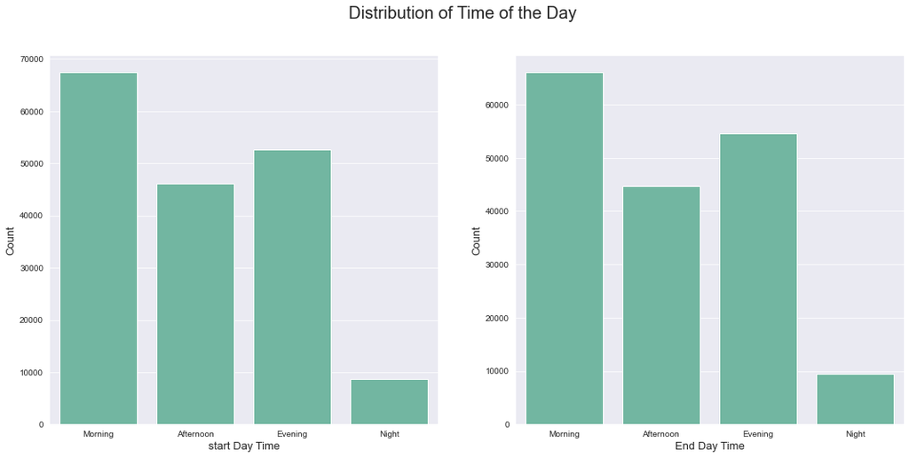

```python
# setting the figure size
fig, axes = plt.subplots(1, 2, figsize=(18,8))
# using the plot_graph function to plot bar plot
plot_day_dist(1, 'start_day_time', 'start Day Time', 'Count' )
plot_day_dist(2, 'end_day_time','End Day Time', 'Count')
```

> From the visual above it seens Most of the bikes trips were done in the morning time, less were done in the evening, even less in the afternoon with the lest frequent rides happening at night. Same goes for end time of the day. The only month in consideration for start month here is February since it is only frebruary that was provided for start month in the dataset while end month is February and March.

### Doing more analysis to explore the count of time of start and end time of trips

```python
df_bike_master.groupby(['start_day_time', 'end_day_time'])['duration_min'].count()
```

```
start_day_time  end_day_time
Morning         Morning         65774
                Afternoon        1610
                Evening            32
                Night               0
Afternoon       Morning            23
                Afternoon       43112
                Evening          2971
                Night               8
Evening         Morning            37
                Afternoon          11
                Evening         51635
                Night             974
Night           Morning           193
                Afternoon           6
                Evening             1
                Night            8565
Name: duration_min, dtype: int64
```

```python
# Getting the total number of trips that start and ends at the same time of the day and vise versa
print('total number of trips that start and ends at the same day time:', len(df_bike_master[df_bike_master['start_day_time'] == df_bike_master['end_day_time']]))
print('total number of trips that start and ends at the same day time:', len(df_bike_master[df_bike_master['start_day_time'] != df_bike_master['end_day_time']]))
```

```
total number of trips that start and ends at the same day time: 169086
total number of trips that start and ends at the same day time: 5866
```

> I observed from my analysis that members whose ride starts and ends at same time of the day are total of **169086** while those members whose ride starts and end in the different times of the day are **5866**

The common start and end time of member's rides are given below:

> Night - Night

> Morning - Morning

> Afternoon - Afternoon

> Evening Evening

> And also with the analysis above, it implies that most of the members engaging with bike-sharing system covering the greater San Francisco Bay starts and ends at same time of the day of which Morning is the most frequent

## 2. What are the distribution of day of the week

```python
df_bike_master.groupby(['start_weekday', 'end_weekday'])['duration_min'].count()
```

```
start_weekday  end_weekday
Sun            Sun            14475
               Mon               37
               Tue                0
               Wed                0
               Thu                0
               Fri                0
               Sat                0
Mon            Sun                0
               Mon            25604
               Tue               37
               Wed                0
               Thu                0
               Fri                0
               Sat                0
Tue            Sun                0
               Mon                0
               Tue            30554
               Wed               30
               Thu                0
               Fri                0
               Sat                0
Wed            Sun                0
               Mon                0
               Tue                0
               Wed            28387
               Thu               39
               Fri                0
               Sat                0
Thu            Sun                0
               Mon                0
               Tue                0
               Wed                0
               Thu            33668
               Fri               44
               Sat                0
Fri            Sun                0
               Mon                0
               Tue                0
               Wed                0
               Thu                0
               Fri            27611
               Sat               52
Sat            Sun               44
               Mon                0
               Tue                0
               Wed                0
               Thu                0
               Fri                0
               Sat            14370
Name: duration_min, dtype: int64
```

**creating function to plot the distribution of weekdays**

```python
#creating a function to plot a bar plot
def plot_week_dist(pltnr, x_col, xlabel, ylabel):
    fig.suptitle('Distribution of Days of the Week', fontsize = 20)
    plt.subplot(1,2, pltnr)
    colors = sb.color_palette()[0]
    sb.countplot(data = df_bike_master, x = x_col, color = colors)
    plt.xlabel(xlabel, fontsize = 13)
    plt.ylabel(ylabel, fontsize = 13)
```

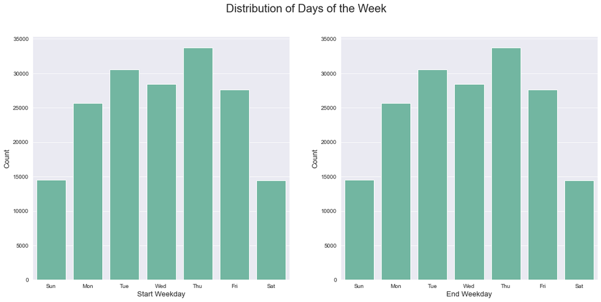

```python
# setting the figure size
fig, axes = plt.subplots(1, 2, figsize=(18,8))
# using the plot_graph function to plot bar plot
plot_week_dist(1, 'start_weekday', 'Start Weekday', 'Count' )
plot_week_dist(2, 'end_weekday','End Weekday', 'Count')
```

> From my exploration of the days of the week, I observed that most trips starts and ends at same day for different days of the week. coupled with the visual above, There are more start and end trips on Thursdays than any other day of the week. This shows that Thursdays are the most busy day of the week for bike trips in the San Francisco Bay Area.

### looking at the distribution of the suggested variables of interest

## 3. Taking a look at Duration of Trips

**Plotting histogram for Duration of Trip**

```python
df_bike_master['duration_min']
```

```
0          869.75
1         1030.90
2          608.17
3           26.42
4           29.88
           ...
174947       8.00
174948       5.22
174949       2.35
174950       2.32
174951       4.52
Name: duration_min, Length: 174952, dtype: float64
```

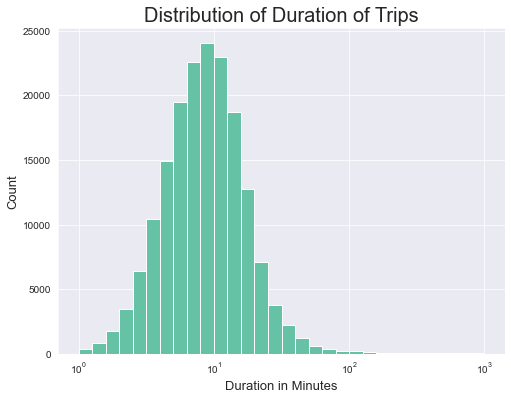

```python
# setting bin edges for the histogram
binedges = 10**np.arange(0 , 3+0.1 , 0.1)

ticks =  [ 0.1 , 0.3 , 1 , 3, 10, 30, 100, 300]
labels = ['{}'.format(v) for v in ticks]

plt.figure(figsize=[8, 6])
plt.hist(data = df_bike_master , x = 'duration_min' ,bins = binedges)

plt.xticks(ticks,labels)

plt.title('Distribution of Duration of Trips', fontsize = 20)
plt.xlabel('Duration in Minutes', fontsize = 13);
plt.ylabel('Count',  fontsize = 13)

plt.xscale('log');
```

Plotting the log transformation of duration in minutes, I observed that there is a steady increase in duration of trip till around ten minutes and started decreasing at eleven minutes.

## 4. distribution of member's age group engaging in the bike trips

**Age intervals [13, 17, 25, 60, 141]**

**corresponding labels ['Teenager','Young Adult','Adult','Senior Citizens']**

```python
# Count of age group counts
df_bike_master['age_groups'].value_counts()
```

```
Adult              140814
Young Adult         30608
Senior Citizens      3530
Teenager                0
Name: age_groups, dtype: int64
```

```python
# Taking the count of age group and assign it age group count
age_group_counts = df_bike_master['age_groups'].value_counts()

# Taking the index of each age group count
age_group_counts_order = age_group_counts.index
```

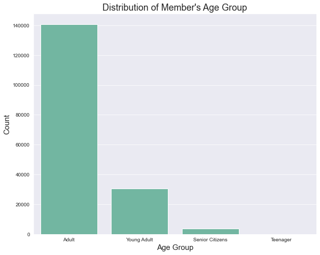

```python
# setting the chart layout
plt.figure(figsize=[10, 8])

colors = sb.color_palette()[0]
sb.countplot(data=df_bike_master, x='age_groups', color = colors, order = age_group_counts_order)

# seeting up the chart labels
plt.title('Distribution of Member\'s Age Group', fontsize = 18)
plt.xlabel('Age Group', fontsize = 15)
plt.ylabel('Count', fontsize = 15)
plt.show()
```

The analysis and visual above shows that Members who are Adult (between the age of 26 to 60) are the ones mostly engaging with the bike trips. Follow by the young adult (between the age of 18 to 25). members who are Senior Citizen around age 60 and above are very little among people engaging with the bike trips. Finally, it is interesting to know that teenagers (specified age ranges from 0 to 17) are not using the bike-sharing system covering the greater San Francisco Bay.

## 5. distribution of member's gender engaging in the bike trips

```python
df_bike_master['member_gender'].value_counts()
```

```
Male      130500
Female     40805
Other       3647
Name: member_gender, dtype: int64
```

**Getting the percentage of member gender engaging with the Bike trip**

```python
# total value in the entire wrangled dataset
Total_val = df_bike_master['member_gender'].count()

# total value count of each category
gender_val = df_bike_master['member_gender'].value_counts()

# The percentage values of each category
percentage_values = (gender_val / Total_val)*100

# Round the percentage value into 2 decimal place
round(percentage_values, 2 )
```

```
Male      74.59
Female    23.32
Other      2.08
Name: member_gender, dtype: float64
```

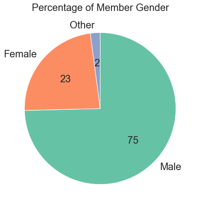

```python
#plotting using plt.pie matplotlib

gender_val = df_bike_master['member_gender'].value_counts()

plt.figure(figsize=[8,7])

plt.pie(gender_val, startangle = 90, labels = gender_val.index, autopct='%0.0f', counterclock = False, textprops={'fontsize': 20});

plt.title('Percentage of Member Gender', fontsize=20);
#  autopct='%.2f' - places the values in the sections
```

The analysis and visual above, it shows that members who are **male** (counts of**130500**) and percentage of 75 are the ones mostly engaging in bike trips.

## 6. user type either subscriber or customer would have effect on frequency of trips

```python
df_bike_master['user_type'].value_counts()
```

```
Subscriber    158386
Customer       16566
Name: user_type, dtype: int64
```

From this analysis we can see that members who are suscribers with count of **158386** out of total of 174952 trips (**this is the total number of trips after my data wrangling process**) are more engaging in the bike sharing system.

With that been said, let us go ahead and see the visual representation of this finding.

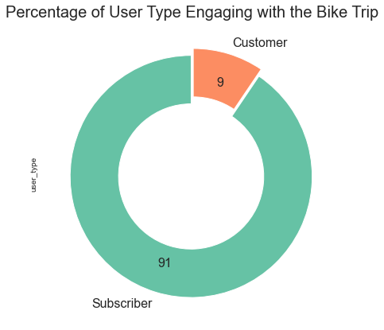

```python
# only "explode" the 2nd slice (i.e. 'Hogs')
explode = (0.03, 0.03)

#create pie chart
plt.figure(figsize=[8,7])

#adjust the text position and explod the donut chart
df_bike_master['user_type'].value_counts().plot(kind="pie",startangle = 90, textprops={'fontsize': 16},
                                                wedgeprops = {'width' : 0.4},
                                                autopct='%0.0f', pctdistance=0.75, explode=explode)

plt.title('Percentage of User Type Engaging with the Bike Trip', fontsize=20)
plt.show()
```

Obviously it is clear from the visual above that members who are suscribers with count of **158386** out of total of 174952 trips (**this is the total number of trips after my data wrangling process**) are more engaging in the bike sharing system.

## 7. Taking a look at bike share during the trip

```python
df_bike_master['bike_share_for_all_trip'].value_counts()
```

```
No     157606
Yes     17346
Name: bike_share_for_all_trip, dtype: int64
```

Taking a look at bike share during the trip.

From my analysis, it appears that most of the members engaging in the bike trips are not sharing thier bikes.

we have **157606** total members who are not sharing thier bikes during thier trips

While only **17346** members shares their bikes during thier trips

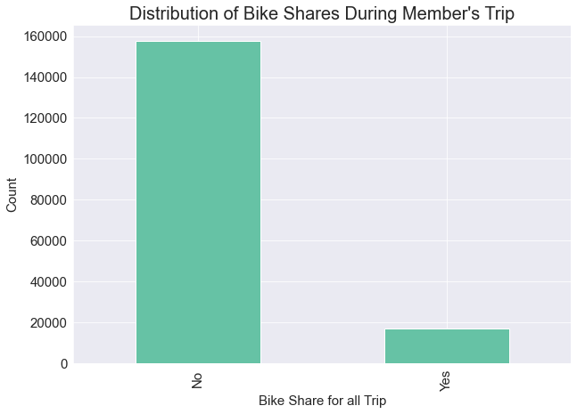

```python
df_bike_master['bike_share_for_all_trip'].value_counts().plot(kind = 'bar', figsize = (10,7), fontsize = 15)

plt.title("Distribution of Bike Shares During Member's Trip", fontsize = 20)
plt.xlabel('Bike Share for all Trip', fontsize = 15)
plt.ylabel('Count', fontsize = 15)

plt.show();
```

From the visual, it appears that most of the members engaging in the bike trips are not sharing thier bikes.

we have **157606** total members who are not sharing thier bikes during thier trips

While only **17346** members shares their bikes during thier trips

### 8. Taking a look at start and end sations

#### checking for the total number of start and end sations in consideration

```python
print('Total number of start station in consideration' ,len(df_bike_master.start_station_name.unique()))
print('Total number of end station in considerationlen' , len(df_bike_master.start_station_name.unique()))
```

```
Total number of start station in consideration 329
Total number of end station in considerationlen 329
```

### Taking the Top 10 Start and End Stations

**Here I will be carrying out my exploration on start and end location based on the top 10 locations to avoid overwhelming axis name during visualization**

```python
# getting the top 10 start stations
top_10_start = df_bike_master['start_station_name'].value_counts().sort_values(ascending = False).head(10)
top_10_start
```

```
Market St at 10th St                                         3649
San Francisco Caltrain Station 2  (Townsend St at 4th St)    3408
Berry St at 4th St                                           2952
Montgomery St BART Station (Market St at 2nd St)             2711
Powell St BART Station (Market St at 4th St)                 2620
San Francisco Caltrain (Townsend St at 4th St)               2577
San Francisco Ferry Building (Harry Bridges Plaza)           2541
Howard St at Beale St                                        2216
Steuart St at Market St                                      2191
Powell St BART Station (Market St at 5th St)                 2144
Name: start_station_name, dtype: int64
```

```python
# getting the top 10 end stations
top_10_end = df_bike_master['end_station_name'].value_counts().sort_values(ascending = False).head(10)
top_10_end
```

```
San Francisco Caltrain Station 2  (Townsend St at 4th St)    4624
Market St at 10th St                                         3709
Montgomery St BART Station (Market St at 2nd St)             3461
San Francisco Ferry Building (Harry Bridges Plaza)           3151
San Francisco Caltrain (Townsend St at 4th St)               2870
Powell St BART Station (Market St at 4th St)                 2854
Berry St at 4th St                                           2782
The Embarcadero at Sansome St                                2341
Steuart St at Market St                                      2264
Powell St BART Station (Market St at 5th St)                 2153
Name: end_station_name, dtype: int64
```

```python
# creating a list for the top 10 start stations
list_top_10_start = ['Market St at 10th St', 'San Francisco Caltrain Station 2  (Townsend St at 4th St)', 'Berry St at 4th St',
                  'Montgomery St BART Station (Market St at 2nd St)', 'Powell St BART Station (Market St at 4th St)',
                  'San Francisco Caltrain (Townsend St at 4th St)', 'San Francisco Ferry Building (Harry Bridges Plaza)',
                  'Howard St at Beale St', 'Steuart St at Market St', 'Powell St BART Station (Market St at 5th St)']
```

```python
# creating a list for the top 10 start stations
list_top_10_end = ['San Francisco Caltrain Station 2  (Townsend St at 4th St)', 'Market St at 10th St',
                     'Montgomery St BART Station (Market St at 2nd St)', 'San Francisco Ferry Building (Harry Bridges Plaza)',
                     'San Francisco Caltrain (Townsend St at 4th St)', 'Powell St BART Station (Market St at 4th St)',
                     'Berry St at 4th St', 'The Embarcadero at Sansome St', 'Steuart St at Market St',
                     'Powell St BART Station (Market St at 5th St)']
```

**Extracting 10 top rows of trips from the entire dataset**

```python
# Extracting 10 top rows of trips from the entire dataset
df_top_10_start = df_bike_master.loc[df_bike_master['start_station_name'].isin(list_top_10_start)]
df_top_10_end = df_bike_master.loc[df_bike_master['end_station_name'].isin(list_top_10_end)]
```

```python
df_top_10_start.head(5)
```

|  | start_time | end_time | start_station_name | end_station_name | bike_id | user_type | member_birth_year | member_gender | bike_share_for_all_trip | start_day_time | end_day_time | start_weekday | end_weekday | start_month | end_month | member_age | age_groups | duration_min |
| --- | --- | --- | --- | --- | --- | --- | --- | --- | --- | --- | --- | --- | --- | --- | --- | --- | --- | --- |
| 0 | 2019-02-28 17:32:10.145 | 2019-03-01 08:01:55.975 | Montgomery St BART Station (Market St at 2nd St) | Commercial St at Montgomery St | 4902 | Customer | 1984 | Male | No | Evening | Morning | Thu | Fri | Feb | Mar | 35 | Adult | 869.75 |
| 35 | 2019-02-28 23:31:16.139 | 2019-02-28 23:49:02.792 | Market St at 10th St | 29th St at Church St | 5938 | Subscriber | 1992 | Female | No | Night | Night | Thu | Thu | Feb | Feb | 27 | Adult | 17.77 |
| 39 | 2019-02-28 23:20:24.089 | 2019-02-28 23:46:19.019 | San Francisco Ferry Building (Harry Bridges Pl... | Yerba Buena Center for the Arts (Howard St at ... | 5411 | Subscriber | 1972 | Male | No | Night | Night | Thu | Thu | Feb | Feb | 47 | Adult | 25.90 |
| 50 | 2019-02-28 23:30:52.471 | 2019-02-28 23:37:33.955 | Market St at 10th St | Victoria Manalo Draves Park | 5407 | Subscriber | 1990 | Female | No | Night | Night | Thu | Thu | Feb | Feb | 29 | Adult | 6.68 |
| 59 | 2019-02-28 23:28:42.709 | 2019-02-28 23:32:41.769 | Montgomery St BART Station (Market St at 2nd St) | Bryant St at 2nd St | 5731 | Subscriber | 1986 | Male | No | Night | Night | Thu | Thu | Feb | Feb | 33 | Adult | 3.98 |

```python
# value count of the top 10 start and end stations and getting their index
sta_counts_start = df_top_10_start['start_station_name'].value_counts()
sta_start_order = sta_counts_start.index

sta_counts_end = df_top_10_end['end_station_name'].value_counts()
sta_end_order = sta_counts_end.index
```

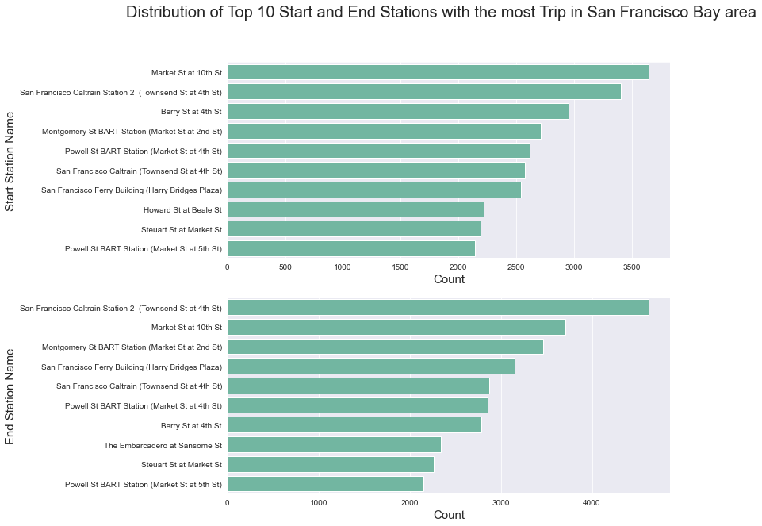

```python
#setting the fig and figsize for the plot
fig, ax = plt.subplots(nrows=2, figsize = [10,10] )

# using seaborn base color
colors = sb.color_palette()[0]

# ploting seaborn count plot for both start and end stations
sb.countplot(data=df_top_10_start, y='start_station_name', color = colors, order = sta_start_order, ax = ax[0])
sb.countplot(data=df_top_10_end, y='end_station_name', color = colors, order = sta_end_order, ax = ax[1])

fig.suptitle('Distribution of Top 10 Start and End Stations with the most Trip in San Francisco Bay area', fontsize = 20)

# setting labels for x and y axis
ax[0].set_xlabel('Count', fontsize = 15)
ax[1].set_xlabel('Count', fontsize = 15)

ax[0].set_ylabel('Start Station Name', fontsize = 15)
ax[1].set_ylabel('End Station Name', fontsize = 15);
```

It appears that **Market St at 10th St** is the most used start station in in San Francisco Bay area with count of **3649**

While **San Francisco Caltrain Station 2 (Townsend St at 4th St)** is the most used end station in in San Francisco Bay area with count of **4624**

### Discuss the distribution(s) of your variable(s) of interest. Were there any unusual points? Did you need to perform any transformations?

> My visual showed that there are more of bike trips that start in the morning follow by the evening time then afternoon while members do not really start their trips in the night. On the other hand more of those bike trips ended in the morning follow by the evening time then afternoon. while members do not really end their trips in the night. And also with the analysis, it was clear that most of the members engaging with bike-sharing system covering the greater San Francisco Bay starts and ends at same time of the day of which Morning is the most frequent

> Then for the days in the week, from my exploration, I observed that most trips starts and ends at same day for different days of the week. coupled with the visual above it implies that, bike-sharing system San Francisco Bay area has Thursday to be the most busiest day of the week for bike trips .

> No analysis and visuals for Month since the only month in consideration for start month here is February and early March

### Of the features you investigated, were there any unusual distributions? Did you perform any operations on the data to tidy, adjust, or change the form of the data? If so, why did you do this?

> **This is to categorize the age of the members engaging with the Bike trips into age gruops for easy analysis and visualization.**

## Bivariate Exploration

### 9. looking at the pairwise correlations present between features in the data.

```python
# Correlation values between all the features in the data
corr = df_bike_master.corr()
```

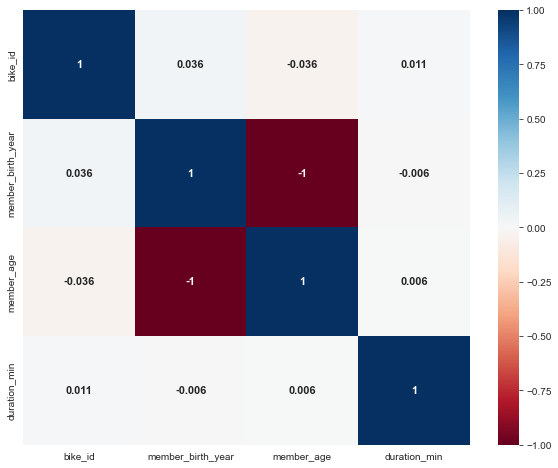

```python
# correlation with heat map
plt.figure(figsize=[10,8])

sb.heatmap(corr, cmap='RdBu', vmin=-1, vmax=1, annot=True,
            annot_kws={'fontsize':11, 'fontweight':'bold'});
```

```python
numeric_var = ['duration_min', 'member_age', 'member_birth_year']
```

**Further investigation on the correlation between the numerical variables**

```
DataFrame Original Shape is  (174952, 18)
Smaple Size Shape =  (500, 18)
```

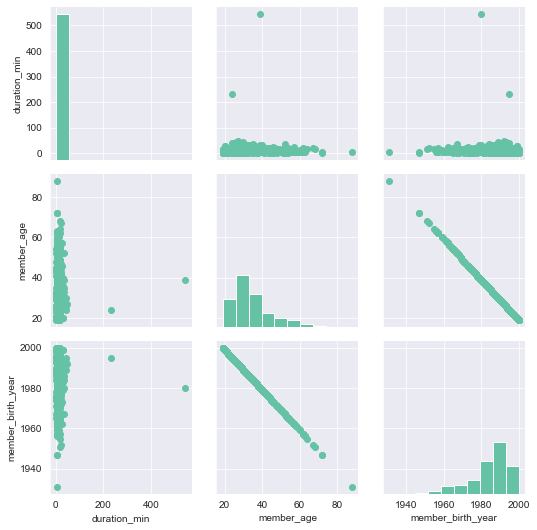

```python
# plot matrix: sample 500 diamonds so that plots are clearer and they render faster
print("DataFrame Original Shape is " ,df_bike_master.shape)

df_bike_master_samp = df_bike_master.sample(n=500  , replace = False)
print("Smaple Size Shape = " ,df_bike_master_samp.shape)

g = sb.PairGrid(data = df_bike_master_samp, vars = numeric_var)
g = g.map_diag(plt.hist)
g.map_offdiag(plt.scatter)

plt.show();
```

**These then mean that I will have to continue my investigation with the categorical variables**

### 10. Exploring member's age groups engaging with bike trip by time of the day

**creating a function to plot a bar plot**

```python
#creating a function to plot a bar plot
def plot_graph(pltnr, x_col, hueval, xlabel, ylabel, yscale):
    fig.suptitle('Effect of Member\'s Age Groups on the Frequency of Trip per Time of the day', fontsize = 20)
    plt.subplot(1,2, pltnr)
    sb.countplot(data = df_bike_master, x = x_col, hue = hueval)
    plt.legend()
    plt.xlabel(xlabel, fontsize = 13)
    plt.ylabel(ylabel, fontsize = 13)
    plt.yscale(yscale)
```

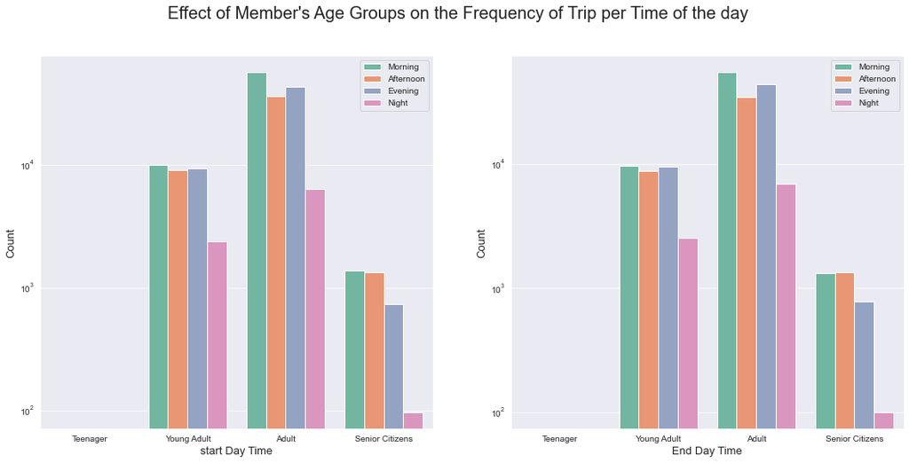

```python
# setting the figure size
fig, axes = plt.subplots(1, 2, figsize=(18,8))
# using the plot_graph function to plot bar plot
plot_graph(1, 'age_groups', 'start_day_time', 'start Day Time', 'Count', 'log')
plot_graph(2, 'age_groups', 'end_day_time', 'End Day Time', 'Count', 'log')
```

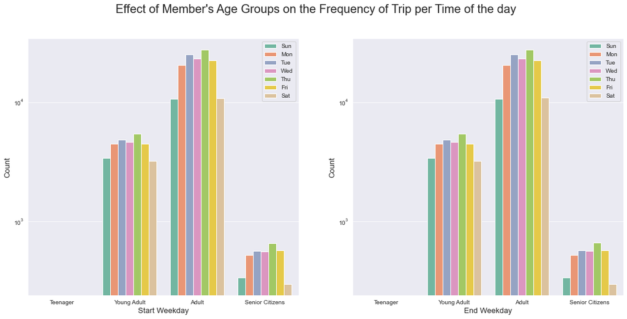

```python
# setting the figure size
fig, axes = plt.subplots(1, 2, figsize=(18,8))
# using the plot_graph function to plot bar plot
plot_graph(1, 'age_groups', 'start_weekday', 'Start Weekday', 'Count', 'log')
plot_graph(2, 'age_groups', 'end_weekday', 'End Weekday', 'Count', 'log')
```

### 11. Exploring duration of ride by day of the week and Time of the Day

```python
df_bike_master['duration_min'].min()
```

```
1.02
```

```python
df_bike_master['duration_min'].value_counts()
```

```
4.53      308
5.38      285
5.08      282
6.15      280
5.10      276
         ...
68.00       1
47.12       1
136.65      1
66.55       1
47.03       1
Name: duration_min, Length: 4429, dtype: int64
```

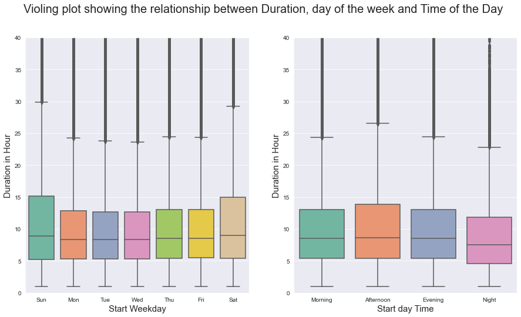

```python
fig, axes = plt.subplots(1, 2, figsize=(15,8))

# creating a supper title for plot
fig.suptitle('Violing plot showing the relationship between Duration, day of the week and Time of the Day', fontsize = 20)

# subplot in 1st row and 1st column
plt.subplot(1, 2, 1)
sb.boxplot(data=df_bike_master, x='start_weekday', y='duration_min')
plt.ylim(0, 40)

# setting label and fontsize for start weekday
plt.xlabel('Start Weekday', fontsize = 15)
plt.ylabel('Duration in Hour', fontsize = 15);


# subplot in 1st row and 2nd column
plt.subplot(1, 2, 2)
sb.boxplot(data = df_bike_master, x='start_day_time', y='duration_min')
plt.ylim(0, 40)

# setting label and fontsize for start time of the day
plt.xlabel('Start day Time', fontsize = 15)
plt.ylabel('Duration in Hour', fontsize = 15);
```

> Same goes for start time of the day, I observed that Morning, Afternoon and Evening has same duration except for a sligth drop at night

### 12. Exploring User Type engaging with bike trip by Time of the day and weekdays

**Creating function to plot bar plot for User type**

```python
#creating a function to plot a bar plot
def plot_chart(pltnr, x_col, hueval, xlabel, ylabel):
    fig.suptitle('Effect of User Type on the Frequency of Trip on Start day Time and End day Time', fontsize = 20)
    plt.subplot(1,2, pltnr)
    sb.countplot(data = df_bike_master, x = x_col, hue = hueval)
    plt.legend()
    plt.xlabel(xlabel, fontsize = 13)
    plt.ylabel(ylabel, fontsize = 13)
```

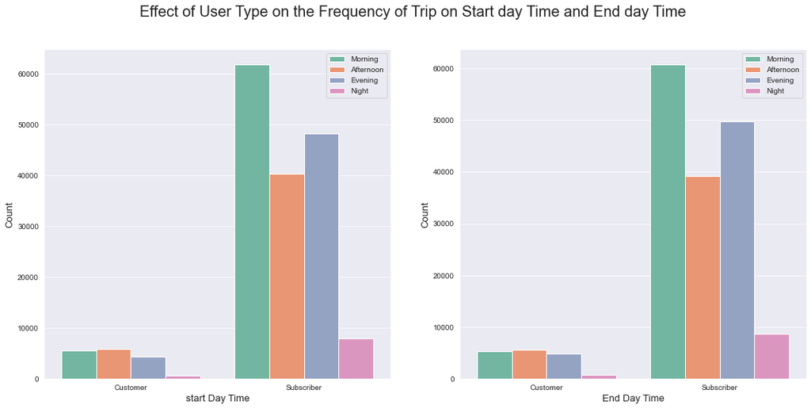

```python
# setting the figure size
fig, axes = plt.subplots(1, 2, figsize=(18,8))
# using the plot_graph function to plot bar plot
plot_chart(1, 'user_type', 'start_day_time', 'start Day Time', 'Count')
plot_chart(2, 'user_type', 'end_day_time', 'End Day Time', 'Count')
```

> Members who are suscribers are the ones really engaging with bike trips by time of the day as there are huge differences observed between the Customers and Suscribers in relationship with their usage of bike sharing system by time of the day.

> Comparing the effect of user typeon the frequency of trips by time of the day, Morning time still seems to stand out in suscribers but Afternoon seens to be the most frequent in customers and this applies for both start and end imes of the day.

**Using plot_chart to plot User type by weekdays**

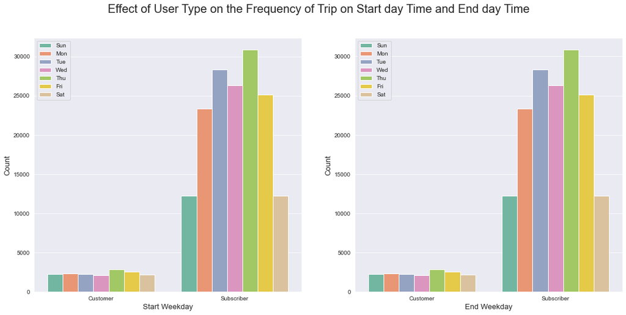

```python
# setting the figure size
fig, axes = plt.subplots(1, 2, figsize=(18,8))
# using the plot_graph function to plot bar plot
plot_chart(1, 'user_type', 'start_weekday', 'Start Weekday', 'Count')
plot_chart(2, 'user_type', 'end_weekday', 'End Weekday', 'Count')
```

> Members who are suscribers are the ones really engaging with bike trips by weekdays as there are huge differences observed between the Customers and Suscribers in relationship with their usage of bike sharing system by weekdays.

> Interestingly Thursday still seems to stand out in both customers and suscribers and this applies for both start and end weekdays.

### 13. Exploring Member Gender Engaging with Bike Trips by Time of the day and weekdays

```python
#creating a function to plot a bar plot
def plot_mem_chart(pltnr, x_col, hueval, xlabel, ylabel):
    fig.suptitle('Effect of Member Gender on the Frequency of Trip on Start day Time and End day Time', fontsize = 20)
    plt.subplot(1,2, pltnr)
    sb.countplot(data = df_bike_master, x = x_col, hue = hueval)
    plt.legend()
    plt.xlabel(xlabel, fontsize = 13)
    plt.ylabel(ylabel, fontsize = 13)
```

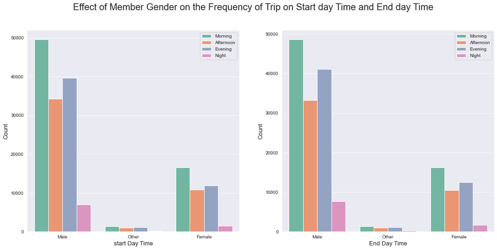

```python
# setting the figure size
fig, axes = plt.subplots(1, 2, figsize=(18,8))
# using the plot_graph function to plot bar plot
plot_mem_chart(1, 'member_gender', 'start_day_time', 'start Day Time', 'Count')
plot_mem_chart(2, 'member_gender', 'end_day_time', 'End Day Time', 'Count')
```

> In start time of the day, morning time appears to be the most frequent time of trips in both start and end time of the day.

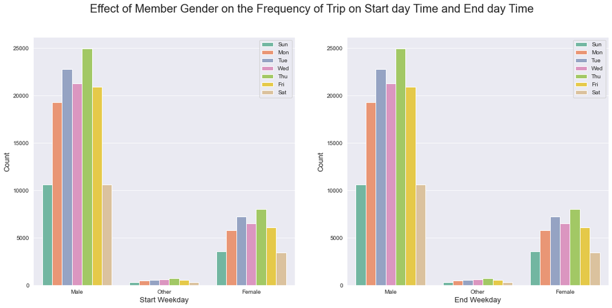

```python
# setting the figure size
fig, axes = plt.subplots(1, 2, figsize=(18,8))
# using the plot_graph function to plot bar plot
plot_mem_chart(1, 'member_gender', 'start_weekday', 'Start Weekday', 'Count')
plot_mem_chart(2, 'member_gender', 'end_weekday', 'End Weekday', 'Count')
```

> Members who are Male members are the ones really engaging with bike trips by weekdays as there are huge differences observed between the Male members and female members in relationship with their usage of bike sharing system by weekdays.

> comparing the relationship between member gender and start weekday, Thursday still seems to stand out in all the member genger.

### 14. Exploring duration in hour and Age Groups

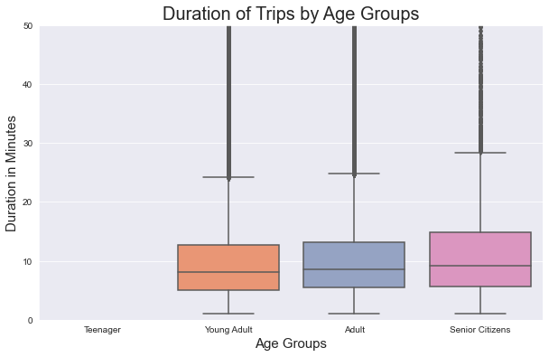

```python
plt.figure(figsize=[10,6])

sb.boxplot(data=df_bike_master, x='age_groups', y='duration_min')
plt.ylim(0, 50)


plt.title("Duration of Trips by Age Groups", fontsize = 20)
plt.xlabel('Age Groups', fontsize = 15)
plt.ylabel('Duration in Minutes', fontsize = 15)

plt.show()
```

From the graph above, it shows that members who are Senior Citizens are having longer duration in the entire bike trips

### 15. Exploring duration in hour and User type

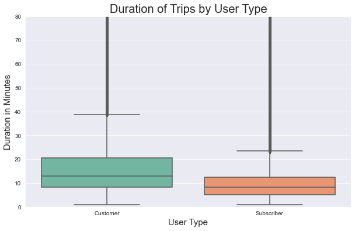

```python
plt.figure(figsize=[10,6])

sb.boxplot(data=df_bike_master, x='user_type', y='duration_min')
plt.ylim(0, 80)


plt.title("Duration of Trips by User Type", fontsize = 20)
plt.xlabel('User Type', fontsize = 15)
plt.ylabel('Duration in Minutes', fontsize = 15)

plt.show()
```

From the chat, I observed that members who are customers have more duration of trip as compared to suscribers

### 16. Looking at the effect of the stations on the frequency of trips per days of the week

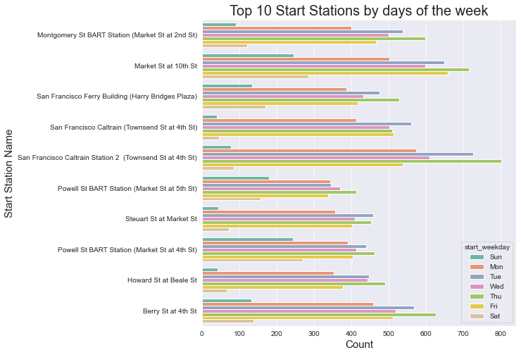

```python
plt.figure(figsize=(8,8))


sb.countplot(data=df_top_10_start, y='start_station_name', hue='start_weekday')

plt.title('Top 10 Start Stations by days of the week', fontsize =20)
plt.ylabel('Start Station Name', fontsize =15)
plt.xlabel('Count', fontsize =15);
```

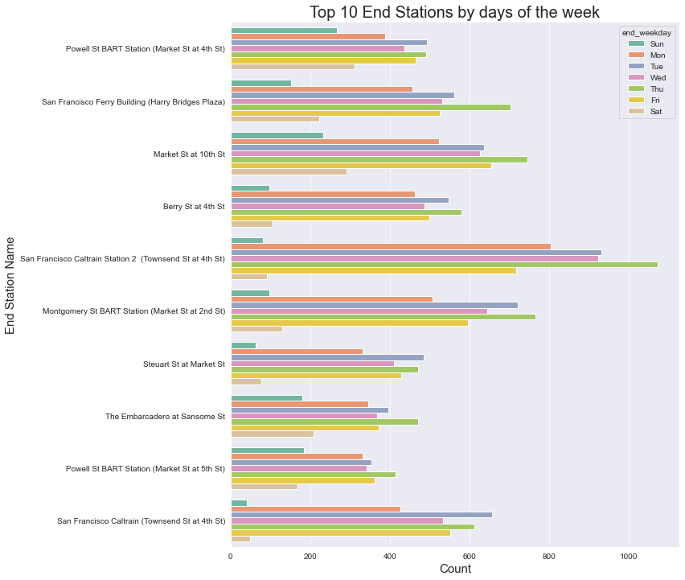

```python
plt.figure(figsize=(10,12))

sb.countplot(data=df_top_10_end, y='end_station_name', hue='end_weekday')

plt.title('Top 10 End Stations by days of the week', fontsize =20)
plt.ylabel('End Station Name', fontsize =15)
plt.xlabel('Count', fontsize =15);
```

Compairing the count of end weekdays with end stations, I observed that **Thursday** which happens to be the most frequent end day of the week that members are engaging with the bike sharing system still happens to be the most frequent start days in the top 10 most used end stations except for **Steuart St at Market St** and **San Francisco Caltrain (Townsend St at 4th St)** but same at **Powell St BART Station (Market St at 4th St)**.

```python
male_member = df_top_10_start.query('member_gender == "Male"')
female_member = df_top_10_start.query('member_gender == "Female"')
other_member = df_top_10_start.query('member_gender == "Other"')
```

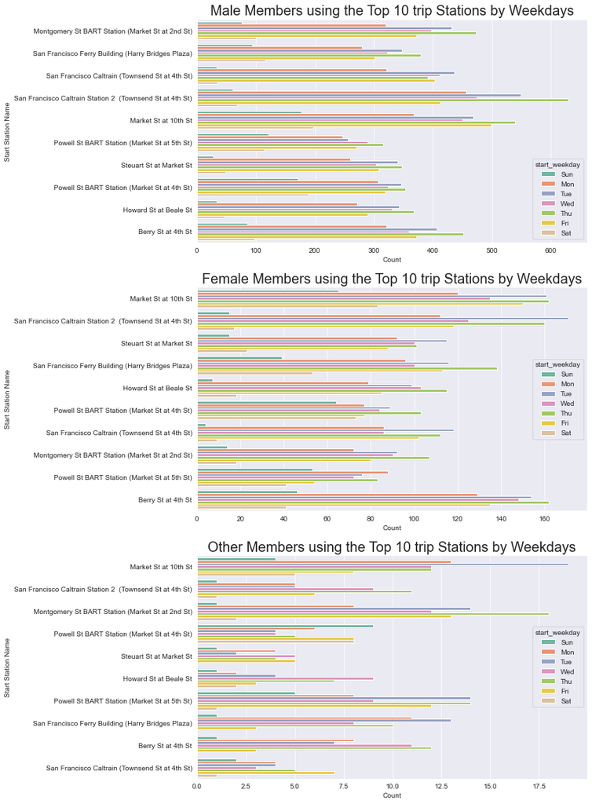

```python
plt.figure(figsize=(10,20))

ax = plt.subplot(3, 1, 1)
sb.countplot(data=male_member, y='start_station_name', hue='start_weekday')
plt.title('Male Members using the Top 10 trip Stations by Weekdays', fontsize = 20)
plt.xlabel('Count')
plt.ylabel('Start Station Name')

ax = plt.subplot(3, 1, 2)
sb.countplot(data=female_member, y='start_station_name', hue='start_weekday')
plt.title('Female Members using the Top 10 trip Stations by Weekdays', fontsize = 20)
plt.xlabel('Count')
plt.ylabel('Start Station Name')

ax = plt.subplot(3, 1, 3)
sb.countplot(data=other_member, y='start_station_name', hue='start_weekday')
plt.title('Other Members using the Top 10 trip Stations by Weekdays', fontsize = 20)
plt.xlabel('Count')
plt.ylabel('Start Station Name');
```

- In male, it was still same Thursday except for **San Francisco Caltrain (Townsend St at 4th St)** where Tuesday is the most frequent
- In female, it was still same Thursday except for **San Francisco Caltrain Station 2 (Townsend St at 4th St)**, **Steuart St at Market St** and **San Francisco Caltrain (Townsend St at 4th St)** where Tuesday is the most frequent
- While a huge exception is noticed in Others gender, **Market St at 10th St** where Tuesday is the most frequent. **Powell St BART Station (Market St at 4th St)** where Sunday is the most frequent.

  Friday and Saturday are equal in terms of frequency in **Steuart St at Market St**.

  Tuesday equals with Thurday in **Powell St BART Station (Market St at 5th St)**.

  Finally, in **San Francisco Caltrain (Townsend St at 4th St)** Friday is the most frequent.

```python
df_top_10_start.user_type
```

```
0           Customer
35        Subscriber
39        Subscriber
50        Subscriber
59        Subscriber
             ...
174906    Subscriber
174907    Subscriber
174908    Subscriber
174940    Subscriber
174948    Subscriber
Name: user_type, Length: 27009, dtype: object
```

```python
Customer = df_top_10_start.query('user_type == "Customer"')
Suscriber = df_top_10_start.query('user_type == "Subscriber"')
```

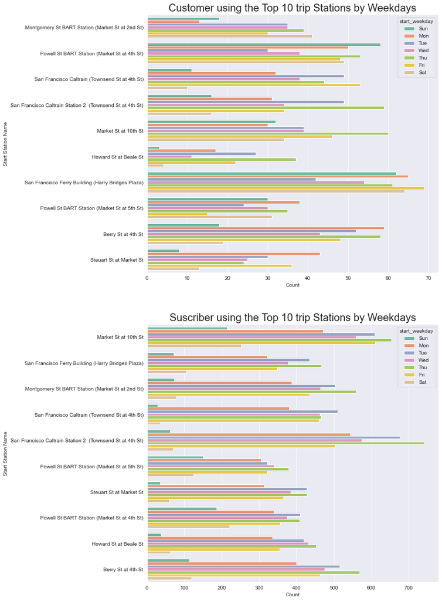

```python
plt.figure(figsize=(10,20))

ax = plt.subplot(2, 1, 1)
sb.countplot(data=Customer, y='start_station_name', hue='start_weekday')
plt.title('Customer using the Top 10 trip Stations by Weekdays', fontsize = 20)
plt.xlabel('Count')
plt.ylabel('Start Station Name')

ax = plt.subplot(2, 1, 2)
sb.countplot(data=Suscriber, y='start_station_name', hue='start_weekday')
plt.title('Suscriber using the Top 10 trip Stations by Weekdays', fontsize = 20)
plt.xlabel('Count')
plt.ylabel('Start Station Name')
```

> Looking at the effect of stations and customers on when most trips were taken, it is only in 3 stations out of the 10 most used stations that Thursday is the most frequent while other 7 station are distributed over other days of the week.

> For Suscribers, Thursday is most frequent in 7 stations and equal in two stations while Tuesday is the most frequent in one station.

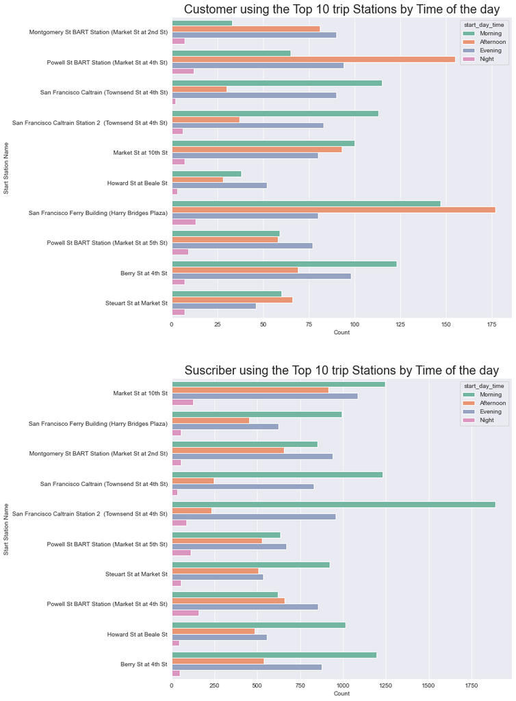

```python
plt.figure(figsize=(10,20))

ax = plt.subplot(2, 1, 1)
sb.countplot(data=Customer, y='start_station_name', hue='start_day_time')
plt.title('Customer using the Top 10 trip Stations by Time of the day', fontsize = 20)
plt.xlabel('Count')
plt.ylabel('Start Station Name')

ax = plt.subplot(2, 1, 2)
sb.countplot(data=Suscriber, y='start_station_name', hue='start_day_time')
plt.title('Suscriber using the Top 10 trip Stations by Time of the day', fontsize = 20)
plt.xlabel('Count')
plt.ylabel('Start Station Name');
```

> Looking at the effect of stations and customers on when most trips were taken, it is only in 4 stations out of the 10 most used stations that Morning time is the most frequent while other 6 stations are distributed Afternoon and Evening.

> For Suscribers, Morning time is the most frequent in 7 stations while Evening is the most frequent in the other 3 stations.

### Talk about some of the relationships you observed in this part of the investigation. How did the feature(s) of interest vary with other features in the dataset?

#### member age groups vs Time of the day and weekdays

**for the start day time**

Observing the relationship between member age and time of the day, I discovered that mature members between the age of **25 to 40** and count of **107467** are the ones mostly engaging with the bike trips per time of the day of which most of them makes their trips in the morning.

Let us as well take note that teenagers (specified age ranges from **0 to 14**) are not using the bike-sharing system covering the greater San Francisco Bay.

**Same for the end day time**

**For the start day of the week**, Members engaging with the bike shairing system are matured members and most of their trips are done Thursday. This is similar to end week days

#### Duration vs Time of the day and weekdays

looking at the relationship between duration in hour and start day of the week and start time of the day

> I observed that Monday to Friday has same duration but sligth increase on Sunday and Saturday.

> Same goes for start time of the day, I observed that Morning, Afternoon and Evening has same duration except for a sligth drop at night

#### User Type vs Time of the day and weekdays

> Members who are suscribers are the ones really engaging with bike trips by weekdays as there are huge differences observed between the Customers and Suscribers in relationship with their usage of bike sharing system by weekdays.

> Interestingly Thursday still seems to stand out.

#### Member Gender vs Time of the day and weekdays

> From the chat above, I observed that Male members are engaging more with the bike-sharing system covering the greater San Francisco Bay area.

> Also for the end weekdays, Thursday is the most frequent except for **Steuart St at Market St** and **San Francisco Caltrain (Townsend St at 4th St)** but same at **Powell St BART Station (Market St at 4th St)**.

> In male, it was still same Thursday except for **San Francisco Caltrain (Townsend St at 4th St)** where Tuesday is the most frequent.

> In female, it was still same Thursday except for **San Francisco Caltrain Station 2 (Townsend St at 4th St)**, **Steuart St at Market St** and **San Francisco Caltrain (Townsend St at 4th St)** where Tuesday is the most frequent.

> Looking at the effect of stations and customers on when most trips were taken, it is only in 3 stations out of the 10 most used stations that Thursday is the most frequent while other 7 station are distributed over other days of the week. For Suscribers, Thursday is most frequent in 7 stations and equal in two stations while Tuesday is the most frequent in one station.

> Looking at the effect of stations and customers on when most trips were taken, it is only in 4 stations out of the 10 most used stations that Morning time is the most frequent while other 6 stations are distributed Afternoon and Evening. For Suscribers, Morning time is the most frequent in 7 stations while Evening is the most frequent in the other 3 stations.

### Did you observe any interesting relationships between the other features (not the main feature(s) of interest)?

> members who are Senior Citizens are having longer duration in the entire bike trips.

> Also members who are customers have more duration of trip as compared to suscribers

## Multivariate Exploration

### 18. looking at Duration and Time and day of the Week by User Type

```python
# Total duration of trips grouped by time of the day and the user type
df_bike_master.groupby(['start_day_time', 'user_type'])['duration_min'].sum()
```

```
start_day_time  user_type
Morning         Customer      107603.00
                Subscriber    644714.61
Afternoon       Customer      153109.95
                Subscriber    450509.19
Evening         Customer       81833.73
                Subscriber    513438.20
Night           Customer       19325.35
                Subscriber     82243.09
Name: duration_min, dtype: float64
```

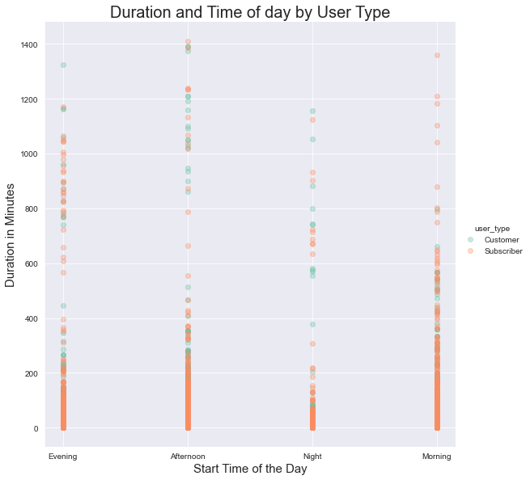

```python
g = sb.FacetGrid(data =  df_bike_master, hue = 'user_type', height = 8)
g.map(plt.scatter, 'start_day_time','duration_min', alpha = 1/3)
g.add_legend()

plt.title('Duration and Time of day by User Type', fontsize = 20)
plt.xlabel('Start Time of the Day', fontsize = 15)
plt.ylabel('Duration in Minutes', fontsize = 15);
```

> The visual above futher strengthes our existing investigations. Most members who are subscribers are engaging with the bike trips in longer duration in the morning period of the day than customers.

> Most interestingly, having compared duration and time of the day by user type, Morning time of the day still happens to be the most frequent time of the day that members are engaging with bike sharing system in San Francisco Bay area.

```python
# Total duration of trips grouped by day of the week and the user type
df_bike_master.groupby(['start_weekday', 'user_type'])['duration_min'].sum()
```

```
start_weekday  user_type
Sun            Customer       63875.09
               Subscriber    143809.26
Mon            Customer       52575.10
               Subscriber    245275.83
Tue            Customer       39090.95
               Subscriber    293683.38
Wed            Customer       43214.48
               Subscriber    271900.51
Thu            Customer       56491.08
               Subscriber    324617.12
Fri            Customer       47189.48
               Subscriber    266911.11
Sat            Customer       59435.85
               Subscriber    144707.88
Name: duration_min, dtype: float64
```

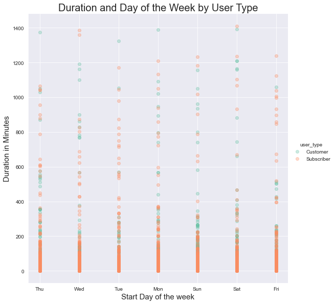

```python
g = sb.FacetGrid(data =  df_bike_master, hue = 'user_type', height = 8)
g.map(plt.scatter, 'start_weekday','duration_min', alpha = 1/3)
g.add_legend()

plt.title('Duration and Day of the Week by User Type', fontsize = 20)
plt.xlabel('Start Day of the week', fontsize = 15)
plt.ylabel('Duration in Minutes', fontsize = 15);
```

### 19. looking at Duration and Time and day of the Week by Age Groups

```python
# Total duration of trips grouped by time of the day and the age group
df_bike_master.groupby(['start_day_time', 'age_groups'])['duration_min'].sum()
```

```
start_day_time  age_groups
Morning         Teenager                0.00
                Young Adult        102631.69
                Adult              631849.67
                Senior Citizens     17836.25
Afternoon       Teenager                0.00
                Young Adult        114243.68
                Adult              472772.14
                Senior Citizens     16603.32
Evening         Teenager                0.00
                Young Adult        103609.39
                Adult              483380.51
                Senior Citizens      8282.03
Night           Teenager                0.00
                Young Adult         28948.13
                Adult               71704.42
                Senior Citizens       915.89
Name: duration_min, dtype: float64
```

```python
# Total duration of trips grouped by day of the week and the age group
df_bike_master.groupby(['start_weekday', 'age_groups'])['duration_min'].sum()
```

```
start_weekday  age_groups
Sun            Teenager                0.00
               Young Adult         47249.03
               Adult              155411.87
               Senior Citizens      5023.45
Mon            Teenager                0.00
               Young Adult         49301.43
               Adult              242359.10
               Senior Citizens      6190.40
Tue            Teenager                0.00
               Young Adult         50308.39
               Adult              275708.06
               Senior Citizens      6757.88
Wed            Teenager                0.00
               Young Adult         50344.61
               Adult              258253.76
               Senior Citizens      6516.62
Thu            Teenager                0.00
               Young Adult         60933.57
               Adult              312855.26
               Senior Citizens      7319.37
Fri            Teenager                0.00
               Young Adult         49339.26
               Adult              257672.91
               Senior Citizens      7088.42
Sat            Teenager                0.00
               Young Adult         41956.60
               Adult              157445.78
               Senior Citizens      4741.35
Name: duration_min, dtype: float64
```

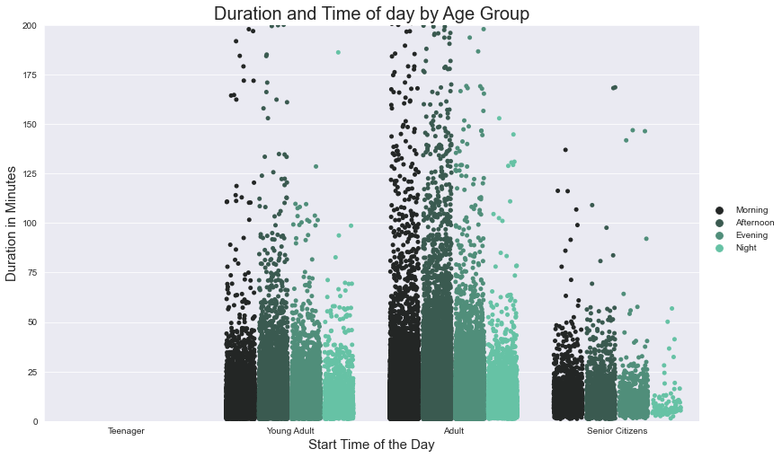

```python
mult_plot = sb.FacetGrid(data = df_bike_master)
mult_plot.map(sb.stripplot, 'age_groups', 'duration_min', 'start_day_time', dodge = True, jitter = .35)

mult_plot.fig.set_size_inches(14, 8)
mult_plot.add_legend()
plt.ylim(0,200)

plt.title('Duration and Time of day by Age Group', fontsize = 20)
plt.xlabel('Start Time of the Day', fontsize = 15)
plt.ylabel('Duration in Minutes', fontsize = 15);
```

> The visual above futher strengthes our existing investigations. Most members who are Adults are engaging with the bike trips in longer duration.

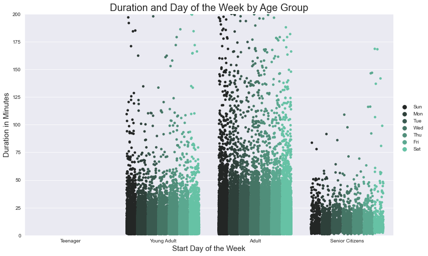

```python
mult_plot = sb.FacetGrid(data = df_bike_master)
mult_plot.map(sb.stripplot, 'age_groups', 'duration_min', 'start_weekday', dodge = True, jitter = .35)

mult_plot.fig.set_size_inches(14, 8)
mult_plot.add_legend()
plt.ylim(0,200)

plt.title('Duration and Day of the Week by Age Group', fontsize = 20)
plt.xlabel('Start Day of the Week', fontsize = 15)
plt.ylabel('Duration in Minutes', fontsize = 15);
```

> The visual above futher strengthes our existing investigations. Most members who are Adults are engaging with the bike trips in longer duration

### 20. looking at Duration and Time and day of the Week by Member Gender

```python
# Total duration of trips grouped by time of the day and the member gender
df_bike_master.groupby(['start_day_time', 'member_gender'])['duration_min'].sum()
```

```
start_day_time  member_gender
Morning         Female           204890.44
                Male             524578.82
                Other             22848.35
Afternoon       Female           156953.12
                Male             428929.64
                Other             17736.38
Evening         Female           149586.77
                Male             431049.59
                Other             14635.57
Night           Female            18268.12
                Male              77899.87
                Other              5400.45
Name: duration_min, dtype: float64
```

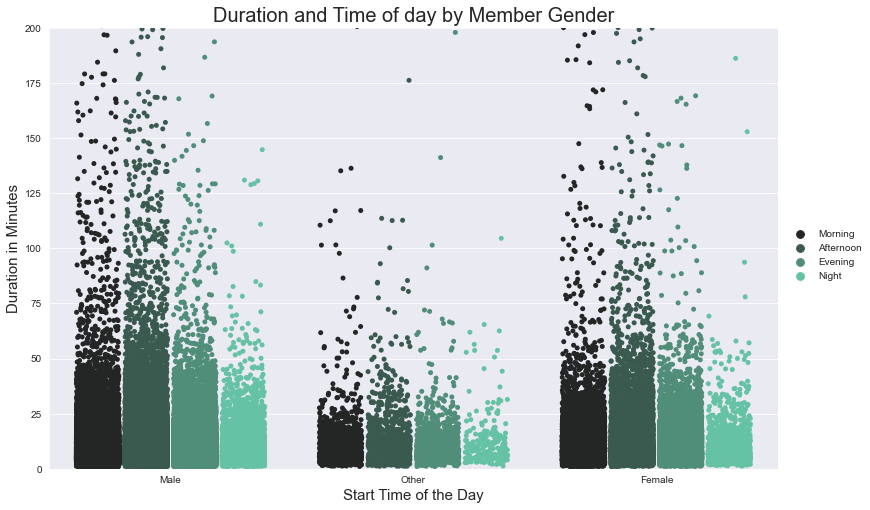

```python
mult_plot = sb.FacetGrid(data = df_bike_master)
mult_plot.map(sb.stripplot, 'member_gender', 'duration_min', 'start_day_time', dodge = True, jitter = .35)

mult_plot.fig.set_size_inches(14, 8)
mult_plot.add_legend()
plt.ylim(0,200)

plt.title('Duration and Time of day by Member Gender', fontsize = 20)
plt.xlabel('Start Time of the Day', fontsize = 15)
plt.ylabel('Duration in Minutes', fontsize = 15);
```

> The visual above futher strengthes our existing investigations. Most members who are Males are engaging with the bike trips in longer duration in the morning period of the day than Females and Others.

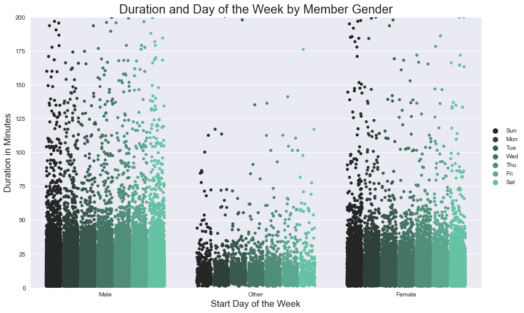

```python
mult_plot = sb.FacetGrid(data = df_bike_master)
mult_plot.map(sb.stripplot, 'member_gender', 'duration_min', 'start_weekday', dodge = True, jitter = .35)

mult_plot.fig.set_size_inches(14, 8)
mult_plot.add_legend()
plt.ylim(0,200)

plt.title('Duration and Day of the Week by Member Gender', fontsize = 20)
plt.xlabel('Start Day of the Week', fontsize = 15)
plt.ylabel('Duration in Minutes', fontsize = 15);
```

> The visual above futher strengthens our existing investigations. Most members who are Males are engaging with the bike trips in longer duration than Females and Others.

> Having compared duration and time of the day by member gender, **Saturday** seems to be the most frequent time of the day that members who are Male. **Friday** for Female members while it is **Thursday** for Others are engaging with bike sharing system in longer duration in San Francisco Bay area.